# Boerhaave 2026: Using R for data analysis

## Mutate: modifying the table (lecture) 👩‍🏫

*Files:* pulseNA.csv.  
*Needs:* 🔴“surveyNA.csv”, 🔴“LcPipeOperator”, 🔴“LcSelect”, 🔴tidyverse.  
*Gives:* if_else, mutate.

The `mutate` function is used to add or modify (new) variables(columns) in the table. It can use the values of existing variables to calculate the values of new ones. This operation does not change the number of rows in the table.

```r
pulse <- read_csv( "pulseNA.csv" , show_col_types = FALSE)

pulse |>
  select( height ) |>
  mutate( isVeryTall = height > 190 ) |>
  head()

pulse |>
  select( height ) |>
  mutate( howTall = if_else( height > 190, "very", "not_very" ) ) |>
  head()

pulse |>
    select( pulse1, pulse2 ) |>
    mutate( pulseDiff = pulse2 - pulse1 ) |>
    head()

pulse |>
    select( pulse1, pulse2 ) |>
    mutate( minPulse = pmin(pulse1, pulse2), maxPulse = pmax(pulse1, pulse2) ) |>
    head()

pulse |>
    select( pulse1, pulse2 ) |>
    mutate(
        minPulse = if_else( pulse1 < pulse2, pulse1, pulse2 ),
        maxPulse = if_else( pulse1 < pulse2, pulse2, pulse1 ) ) |>
    head()
```

## Mutate: modifying the table (exercise) 📖

*Files:* pulseNA.csv, survey.csv.  
*Needs:* 🔴“LcMutate”, “pulseNA.csv”, 🔴“survey.csv”, if_else, 🔴“LcMutate”, 🔴tidyverse.  
*Gives:* case_when, geom_line.

1. Take the following vectors `weight` (pound) and `height` (inch) and store them as variables(columns) of a tibble. Add a column BMI to this tibble where $BMI=weight_{(kg)}/height_{(m)}^2$, and round the BMI values to one decimal place. Note that $1(in) = 0.0254(m)$ and $1(lb) = 0.4535923(kg)$.

```r
weight <- c( 113, 137, 153, 142, 133, 123, 131, 136 ) # unit: pound
height <-  c( 66, 72, 69, 68, 68, 69, 70, 70 )        # unit: inch
```

2. The following table is one of many BMI classifications:

|  | classification | bmi |
| --- | --- | --- |
| 1 | underweight | <18.5 |
| 2 | normal | 18.5-24.9 |
| 3 | overweight | 25-29.9 |
| 4 | obese | >=30 |

Add the variable `BMI_class` to the `pulse` tibble based on the classification in the table above. Use the function [case_when](https://dplyr.tidyverse.org/reference/case_when.html) as a better alternative for `if_else`.

3. Add the variable `age_group` to `survey` based on the following age classification:

|  | classification | age | notation |
| --- | --- | --- | --- |
| 1 | adult | >19 | (19,∞) |
| 2 | adolescent | >=10 and <=19 | [10,19] |
| 3 | child | >=1 and <=9 | [1,9] |
| 4 | infant | <1 | (-∞,1) |

**Solution…**

```r
# 1
d <- tibble(
  weight = c( 113, 137, 153, 142, 133, 123, 131, 136 ), # unit: pound
  height = c( 66, 72, 69, 68, 68, 69, 70, 70 )          # unit: inch
)

d |>
  mutate(weight_kg=weight*0.4535923, height_m=height * 0.0254) |>
  mutate(BMI=round(weight_kg/(height_m)^2, 1) ) |>
  select(weight, height, BMI)

# 2, bad solution, think about BMI set to 24.95
pulse<- read_csv("pulseNA.csv", show_col_types = FALSE)

pulse |>
  mutate(BMI=round( weight/((height/100)^2), digits = 1)) |>
  mutate(BMI_class = case_when(
                BMI < 18.5 ~ "underweight",
                BMI >= 18.5 & BMI <= 24.9 ~ "normal",
                BMI >= 25   & BMI <= 29.9 ~ "overweight",
                BMI >= 30 ~ "obese"
              )
      )

# 2, better solution
# case_when checks conditions in sequence, the second one is checked only if the first is FALSE,
# therefore in the second condition it is not necessary to check that the first was FALSE.

pulse |>
  mutate(BMI=round( weight/((height/100)^2), digits = 1)) |>
  mutate(BMI_class = case_when(
                BMI < 18.5 ~ "underweight",
                BMI < 25 ~ "normal",           # here we know already that BMI >= 18.5
                BMI < 30 ~ "overweight",       # here we know already that BMI >= 25
                TRUE ~ "obese"                 # TRUE means: all other cases
              )
      )


# 3
survey <- read_csv("pulseNA.csv", show_col_types = FALSE)
survey_age_groups <- mutate(survey, age_group = case_when(
                age <= 1 ~ "infant",
                age <= 9 ~ "child",
                age <= 19 ~ "adolescent",
                TRUE ~ "adult"
              )
      )
survey_age_groups

# Note: this solution seemingly solves the exercise, however there is a flaw!
# You can verify this, the following query must return empty:
#
#      survey_age_groups |>  filter(age_group=="adult" & age < 20)
#
# But it is not, why is this?
```

## Select & Filter: Survey dataset (exercise) 📖

*Files:* survey.csv, survey.csv.gz.  
*Needs:* “|>”, head, tail, “tidyverse”, filter, nrow, select, is.na, range, “|>”, “%in%”, “RelOps”.  
*Gives:* “survey.csv”.  
*Practices:* filter, nrow, select, is.na, range, “|>”, “%in%”, “RelOps”.

### Survey dataset

The survey data set is available as comma-delimited (`.csv`) file: `survey.csv` (or additionally compressed as `survey.csv.gz`). This data frame contains the responses of 233 Statistics I students at the University of Adelaide to a number of questions. Here we use a slightly modified version of the `survey` data from the R `MASS` package.

| Variable | Explanation |
| --- | --- |
| name | Name of a participant |
| gender | Sex (male/female) |
| span1 | Span (distance from tip of thumb to tip of little finger of spread hand) of writing hand (cm) |
| span2 | Span of non-writing hand (cm) |
| hand | Writing hand of student (left/right) |
| fold | Fold your arms! which is on top? (right/left/neither) |
| pulse | Pulse measurement (rate per minute) |
| clap | Clap your hands! which is on top? (right/left/neither) |
| exercise | Frequency of exercise (freq/some/none) |
| smokes | How much the student smokes (heavy/regul/occas/never) |
| height | Height (cm) |
| m.i | whether the student expressed height in imperial (feet/inches) or metric (centimetres/metres) units. (metric/imperial) |
| age | Age of the student (years) |

### Queries

1. Select teenagers, assume `age` range between and including 10 and 19.
2. Select all females with `pulse` equal to 60.
3. Select all male teenagers with `pulse` above 60.
4. How many males do smoke and never exercise?
5. How many females never smoke and frequently exercise?
6. Produce the following tibbles:

   6.1 Personal information {Name,Age,Gender,Height} of all teenagers.

   6.2 Personal information of males with `height` between and inclusive 170 to 180.
7. Has survey data missing `pulse` values? If so how many? What about `age`?
8. What is the percentage of males who never smoke and frequently exercise? Do the same for female.
9. What is the age range in teenagers? You may use the range function (?range).
10. How many males do smoke and never exercise? Use ‘%in%’ operator.

**Solution…**

```r
survey <- read_csv("survey.csv", show_col_types = FALSE)
# 1)
survey |> filter(10<=age & age<20)


# 2)
survey |> filter(pulse==60 & gender=="female")

# 3)
survey |> filter(pulse>60 & gender=="male" & (10<=age & age<20) )

# 4)
#
# The conditions are 'do smoke' and 'never exercise'.
# With 'do smoke' we have the categories {regul,occas,heavy} therefore 'or' (|)
# logical connective is in place. For 'never exercise' we have the category 'none'.
# Since both conditions must be true we will have the 'and' (&) logical connective.

survey |>
  filter((smokes=="regul" | smokes=="occas" | smokes=="heavy") & exercise=="none" & gender=="male" ) |>
  nrow()
# Alternatively, a shorter condition for 'smokes' is smokes!="never". It means accept
# all values for 'smokes' as long as it is not equal to "never" and those are
# exactly {regul,occas,heavy}.

survey |> filter(smokes!="never" & exercise=="none" & gender=="male" ) |> nrow()

# 5)
survey |> filter(smokes=="never" & exercise=="freq" & gender=="female") |> nrow()

# 6)
    ### 6,1
    survey |> select(Name=name, Age=age, Gender=gender, Height=height) |>
      filter(10<=Age & Age<20)

    ### 6.2
    survey |> select(Name=name, Age=age, Gender=gender, Height=height) |>
      filter(170>=Height & Height<=180 & Gender=="male")

# 7)
survey |> filter(is.na(pulse)) |>  nrow()
survey |> filter(is.na(age)) |>  nrow()


# 8) Extra exercise
# men
none_smoker_sportsmen <-  survey |>
  filter(smokes=="never"  & exercise=="freq" & gender=="male")  |>
  nrow()
total_men <- survey |> filter(gender=="male") |>  nrow()
none_smoker_sportsmen / total_men

# women : replace the condition gender=="male" into gender=="female"

# 9)
survey |> filter(10<=age & age<20) |> pull(age) |>  range()

# 10)
survey |> filter( (smokes %in% c("regul","occas", "heavy")) & exercise=="none" & gender=="male" ) |> nrow()
```

# Data manipulation 2/3

## Data Read/Write (lecture) 👨‍🏫

### Common Data File formats

- `.rds` — R’s single-object data format [`saveRDS()`, `readRDS()`].
- `.rda` or `.RData` — R’s workspace data format, saving multiple R objects [`save()`, `load()`].
- `.csv` — Comma-separated values, a common format for tabular data. [`read_csv()`, `write_csv()`]
- `.tsv` or `.txt` — Tab-separated or plain text files, often used for data files. [`read_tsv()`, `write_tsv()`]
- `.xlsx` or `.xls` — Excel spreadsheet files (supported with `readxl` or `openxlsx` packages).
- `.json` — JSON format, often used for web data (supported with `jsonlite` package).
- `.xml` — XML format, used for hierarchical data (supported with `XML` or `xml2` packages).
- `.sav`, `.sas7bdat`, `.dta` — Proprietary formats from SPSS, SAS, and Stata (`haven` or `foreign` packages).
- `.yaml` - Data serialisation language (`yaml` package) ([yaml.org](https://yaml.org/), [pecification](https://yaml.org/spec/1.2.2/)).

In R, data types vary in the **level of meta-information** they can hold, which refers to the ability to store additional descriptive data about the dataset beyond the raw values.

1. **Vectors**: The most basic structure, they hold atomic data (numeric, character, etc.) with minimal metadata like length and type.
2. **Matrices and Arrays**: Extend vectors by organizing data into two or more dimensions. They allow metadata like dimension names (`rownames`, `colnames`, `dim` etc.) but are still limited in complexity.
3. **Data Frames**: A more flexible format, storing heterogeneous data (different types in columns) with richer metadata like column names, class attributes for specific columns (e.g., factors), additional metadata about printing behavior.
4. **Lists**: Highly flexible, they can store any type of R object, including additional metadata and nested structures. Less flexible for tabular analysis.
5. **Specialized Objects**: Formats like `S3`, `S4`, and `R6` objects can include extensive metadata via attributes, enabling complex data structures with custom methods.

The higher the level of abstraction (like tibbles or specialized objects), the more meta-information the format can hold.

> WARNING: writing and reading between different data file formats may lead to loss of meta information.

## Data Read/Write (exercise) 📖

### Data Read/Write

1. **Data format** In the `survival` package use the small dataset `aml` and export it to the following data formats given `Filename` and `Functions`. Functions are available via the `tidyverse` and `haven` package.

```python
Filename     Storage     Format  Functions           Package
aml.csv      ASCII Text  CSV     read_csv/write_csv  tidyverse
aml.dta      binary      STATA   read_dta/write_dta  haven
aml.rds      binary      R       read_rds/write_rds  tidyverse  (<=> readRDS/saveRDS)
aml.sas7bdat binary      SAS     read_xpt/write_xpt  haven
aml.sav      binary      SPSS    read_sav/write_sav  haven
aml.tsv      ASCII Text  TSV     read_tsv/write_tsv  tidyverse
```

2. **Prepare SPSS data in R** The SPSS data format can:
1. hold **labels on each variable** as a short description of the variable.
2. **label the values of a variable** in case of categorical variables.

Labeling a variable (column) is achieved by assigning the attribute `label` to it with a value, with the value being the description of the column (see ?attr). The labels of a categorical variable are defined as a key/value pair (see ?haven::labelled).

Take the `survival` package table `aml` and create and SPSS equivalent object in R, where:

- variables have labels as described in the `aml` help page (?survival::aml)
- variable `aml$x` has values 1 and 2 for its levels `Maintained` and `Nonmaintained` respectively

Finally export the created SPSS object to a file, say `aml.sav` and read it back into R and check whether the labels are maintained.

3. **Excel sheets** Read an excel sheet file of your own data using the function exported by `readxl` R package, namely `read_xls()` or `read_xlsx()`. You may need to install `readxl` R package.

**Solution…**

```r
# 1)
#
library(haven)
library(survival)  # aml dataset
# export
aml |> write_sav("aml.sav")      # SPSS
aml |> write_csv("aml.csv")      # CSV
aml |> write_tsv("aml.tsv")      # TSV
aml |> write_dta("aml.dta")      # Stata
aml |> write_xpt("aml.sas7bdat") # SAS
aml |> write_rds("aml.rds")      # Natvie R
# import
aml_sav <-read_sav("aml.sav")
aml_tsv <-read_tsv("aml.tsv", show_col_types = FALSE)
aml_csv <-read_csv("aml.csv", show_col_types = FALSE)
aml_dta <-read_dta("aml.dta")
aml_sas <-read_xpt("aml.sas7bdat")
aml_rds <-read_rds("aml.rds")

# The variables time and status are vectors whereas variable x is a factor with meta-information
# Inspect and compare the original aml$x  class  with all other imports.
#
# solution 1.1)
class(aml$x)
class(aml_sav$x)
class(aml_dta$x)
# etc.


# solution 1.2) Alternatively: use of map function
#
# Object names (objs) are checked for their type (class) one by one
# using map function. The map function will be explained in later
# lectures. See also ?base::get and ?setNames.
objs <- paste("aml", c("sav", "tsv", "csv", "dta", "sas", "rds"), sep="_")
map(setNames(objs,objs), ~ class(get(.x)$x))

# 2)
#
# SPSS variables and variable labels can be labelled. It is possible, using
# haven R package, to create these labels manually so they can be exported
# to a file for usage in the SPSS environment if needed.
#
# The variables are labelled using the R attributes assignments:
attr(x = aml$time,which = "label")  <- "survival or censoring time"
attr(x = aml$status,which = "label")  <- "censoring status"
attr(x = aml$x,which = "label")  <- "maintenance chemotherapy status"
# Values of a variable can be labelled with haven::labelled function:
aml[["x"]] <- labelled(aml[["x"]], c(Maintained=1, Nonmaintained=2))
write_sav(aml,"aml.sav")
aml_sav <- read_sav("aml.sav")


# 3)
#
# Read one of your own excel sheets using `readxl` R package functions,
# e.g. read_xlsx. If you do not have an excel sheet then it is a good
# practice to create an excel sheet manually and try to read it into R
# environment.
#
```

## Descriptive statistics: (group) summaries (lecture) 👩‍🏫

*Files:* pulseNA.csv.  
*Needs:* “pulseNA.csv”, “survey.csv”, 🔴tidyverse.  
*Gives:* drop_na.

Often we are interested in descriptive measures of random variables. Examples are mean, median, standard deviation etc. in numeric values. This is achieved by the function `summarise`.

```r
pulse |> summarise(mean_height=mean(height), sd_height=sd(height))
pulse |> summarise(mean_height=mean(height), sd_height=sd(height), size=n())
pulse |> summarise(mean_height=mean(pulse1, na.rm=TRUE), size=n())
```

Summaries can also be derived based on groups which are created from the categorical variable(s) in the dataset.

```r
# group/summarise :  mean age per exercise group
#
pulse |>
  group_by(exercise) |>
  summarise(mean_age=mean(age))

# handling missing values : is.na/drop_na
#
pulse |>
  filter(!is.na(exercise)) |>
  group_by(exercise) |>
  summarise(mean_age=mean(age, na.rm=TRUE))

# drop all observations with missing value(s)
#
pulse |>
  drop_na() |>
  nrow()

# drop observations with missing gender value only
#
pulse |>
  drop_na(gender) |>
  nrow()

# group/summarise :  mean age per exercise group with missing values removed
#
pulse |>
  drop_na() |>
  group_by(exercise) |>
  summarise(mean_age=mean(age))

# summarise vs mutate ; note that summarise drops the group variable
# but mutate does not, to drop groups use ungroup()
#
pulse |> group_by(gender) |> summarise(size=n())
pulse |> group_by(gender) |> mutate(size=n())
pulse |> group_by(gender) |> mutate(size=n()) |>  ungroup()

# group_by :  multiple variables
#
# Note the message: 'summarise()` has grouped output by 'gender'.
# You can override using the `.groups` argument.'
#
pulse |> drop_na() |>
  group_by(gender, exercise) |>
  summarise(mean_age=mean(weight))

# silent the message on 'summarise' with multiple variables with the
# argument .groups='drop'
pulse |>
  drop_na() |>
  group_by(gender, exercise) |>
  summarise(mean_age=mean(weight), .groups = 'drop')

# counts, frequency tables
pulse |> group_by(gender) |>  summarise(size=n())
pulse |> count(gender)
pulse |> count(age,gender)

# group/mutate
#
pulse |>
  count(gender, exercise) |>
  group_by(gender) |>
  mutate(proportion_within_gender=n/sum(n)) |>
  mutate(percentage_within_gender=round(proportion_within_gender*100,1)) |>
  arrange(gender, desc(percentage_within_gender)) |>
  ungroup()
```

## Descriptive statistics: (group) summaries (exercise) 📖

*Files:* pulseNA.csv.  
*Needs:* 🔴“LcSummarise”, “pulseNA.csv”, “survey.csv”, 🔴“LcMutate”, 🔴tidyverse.  
*Gives:* slice_head.

Use the pulse dataset to answer the following:

1. Per gender, calculate the mean and the standard deviation of the pulse before the exercise. Find how to perform these calculations with ignoring missing values. Name the columns `meanPulseBefore` and `sdPulseBefore`.
2. How many students were there in each year of the experiment?
3. Per year, calculate the number of students and the number of missing values in the `exercise` column. Provide the results in a single table with columns `year`, `studentsNum`, `missingExerciseNum`.
4. For each `gender` and `ran` levels, build a table with min, median, and max of known pulses after the exercise.
5. Give a summary of number of missing age values per exercise group.
6. Retrieve the top 3 tallest individuals in males and in females. The final result must be empty of any grouping.

In the survey dataset:

7. What is the second most common choice (left or right) in variables hand, fold and clap?

**Solution…**

```r
pulse <- read_csv("pulseNA.csv")

# 1
pulse |>
    group_by( gender ) |>
    summarize( meanPulseBefore=mean(pulse1, na.rm=TRUE), sdPulseBefore=sd(pulse1, na.rm=TRUE) )

# 1 : alternative solution
pulse |>
    filter( !is.na(pulse1) ) |>
    group_by( gender ) |>
    summarize( meanPulseBefore=mean(pulse1), sdPulseBefore=sd(pulse1) )

# 2
pulse |> count( year )

# 3
pulse |>
    group_by( year ) |>
    summarize( studentsNum=n(), missingExerciseNum=sum( is.na(exercise) ) )

# 4
pulse |>
    filter( !is.na(pulse2) ) |>
    group_by( gender, ran ) |>
    summarize( minPulse=min(pulse2), medianPulse=median(pulse2), maxPulse=max(pulse2) )

# 5
pulse |> group_by(exercise) |>  summarise(missings=sum(is.na(age)))

# 6
pulse |>
  drop_na(gender, exercise) |> # remove rows with NA in gender and exercise
  group_by(gender) |>          # with each gender group
  arrange(height) |>           # order the group
  slice_head(n=3) |>           # extract top 3
  ungroup()                    # remove remaining groups


survey <- read_csv("survey.csv", show_col_types = FALSE)

# 7
survey |> count(hand,fold,clap) |>  arrange(desc(n)) |>  slice(2)
```

## Reshape tables (lecture) 👨‍🏫

*Files:* pulseNA.csv, survey.csv.  
*Needs:* “pulseNA.csv”, “survey.csv”, 🔴tidyverse.

Two main functions to manipulate the layout of the table, pivot_longer transforms the table from wide to long format and pivot_wider does the opposite, converts the table from long to wide format.

**pivot_longer** function allows collapsing ‘similar’ variables into one variable while guaranteeing the data set’s consistency. For example take the variables pulse1 and pulse2 in the following subset of the pulse data set:

```r
pulses <- pulse  %>%
      select(name,pulse1,pulse2)  %>%
      head(3)
pulses
```

```
# A tibble: 3 × 3
  name     pulse1 pulse2
  <chr>     <dbl>  <dbl>
1 Bonnie       86     88
2 Melanie      82    150
3 Consuelo     96    176
```

We can transform the table as such that all pulse values are under a single variable, say pulse:

```r
# 'pulse1' and 'pulse2' will become categories in 'pulse' variable
dfLong <- pulses %>%
            pivot_longer(c(pulse1, pulse2), names_to = "pulse", values_to = "level")
dfLong
```

```
# A tibble: 6 × 3
  name     pulse  level
  <chr>    <chr>  <dbl>
1 Bonnie   pulse1    86
2 Bonnie   pulse2    88
3 Melanie  pulse1    82
4 Melanie  pulse2   150
5 Consuelo pulse1    96
6 Consuelo pulse2   176
```

**pivot_wider** function does the opposite of `pivot_longer`, going from long to wide format:

```r
dfWide <- dfLong %>% pivot_wider(names_from = "pulse", values_from = "level")
dfWide  # is identical to the original 'pulses' tibble
```

### Plotting

Often reshaping of the data is needed for visualisation. For example we would like to compare pulse1 and pulse2 variables with a boxplot. You may plot pulse1 and pulse2 in separate plots one after the other:

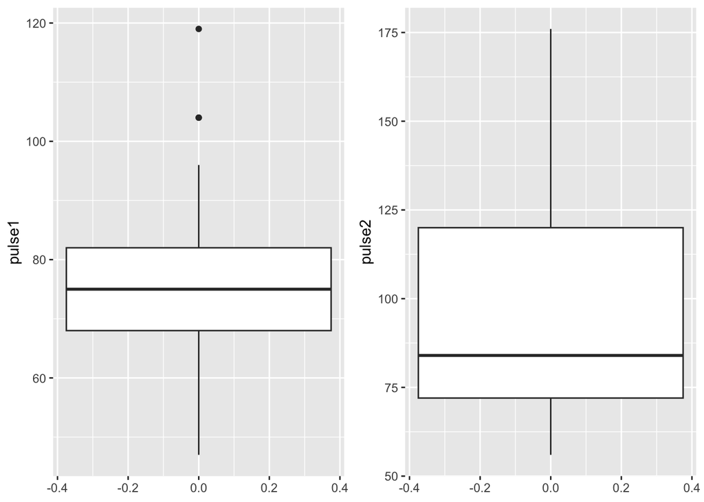

```r
# For illustration we will use the R package gridExtra for arranging plots on screen.
#
suppressMessages(library(gridExtra))

# pulse1 boxplot
bp1 <- ggplot(pulse |>  drop_na()) +  # remove missing
  aes(y=pulse1) +
  geom_boxplot()

# pulse2 boxplot
bp2 <- ggplot(pulse |>  drop_na()) +  # remove missing
  aes(y=pulse2) +
  geom_boxplot()

grid.arrange(bp1, bp2, ncol=2)
```

As you can see the y-scale of each plot is set dynamically and can be misleading. To resolve this, we would need a single plot with aesthetic mapping of x being the categorical variable pulse and y the pulse values as was shown above.

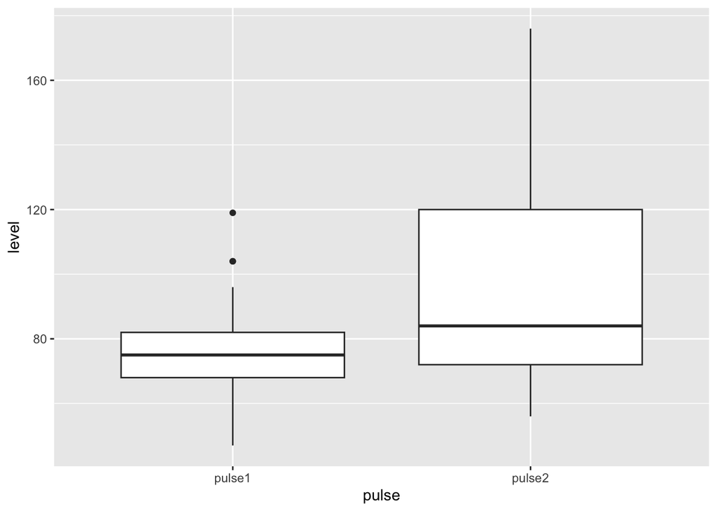

```r
ggplot(pulse |>
         drop_na()  |>   # remove missing
         pivot_longer( c(pulse1,pulse2), names_to = "pulse", values_to = "level")
       ) +
  aes(x=pulse, y=level) +
  geom_boxplot()
```

### Cross tables

Another situation where pivoting plays a role is with cross-tabulation. Cross-tables are used to display the distribution of two or more categorical variables in a compact way. Take the following count table of age,gender groups:

```r
age_sex_group_counts  <- tibble(sex = c("female", "female", "female", "male", "male", "male", "male"),
       age = c(18, 19, 20, 18, 19, 21, 22),
       count = c(1, 1, 2, 1, 2, 2, 1) )
age_sex_group_counts
```

```
# A tibble: 7 × 3
  sex      age count
  <chr>  <dbl> <dbl>
1 female    18     1
2 female    19     1
3 female    20     2
4 male      18     1
5 male      19     2
6 male      21     2
7 male      22     1
```

Here for each age group there are two entries, one for male and one for female, when there was `count` data available. A better way to represent the data is shown below where sex categories are set as separate columns:

```r
age_sex_group_counts |>  pivot_wider(names_from = sex, values_from = count)
```

```
# A tibble: 5 × 3
    age female  male
  <dbl>  <dbl> <dbl>
1    18      1     1
2    19      1     2
3    20      2    NA
4    21     NA     2
5    22     NA     1
```

## Reshape tables (exercise) 📖

*Files:* pulseNA.csv, survey.csv.  
*Needs:* 🔴“LcSummarise”, “survey.csv”, “pulseNA.csv”, 🔴“LcMutate”, 🔴tidyverse.

In the survey dataset:

1. With the `count` function, part of tidyverse, you can calculate the category frequencies in a variable or multiples variables, see `?count` for details. Produce the following cross-tables:
1. `gender` as rows and `exercise` as columns
2. `exercise` as rows and `gender` as columns
3. `smokes` as rows and `exercise` as columns
4. Can you find other interesting combinations?
2. Produce the following count summary per `gender` from variables `fold` and `clap` combined in the `survey` dataset.

```
# A tibble: 2 × 4
  gender  left neither right
  <chr>  <int>   <int> <int>
1 female    67      30   137
2 male      66      37   129
```

3. For each smokes category calculate the writing hand distribution in percentages. The result is a cross table with `smokes` categories as rows `hand` categories as columns.

In the pulse dataset:

4. Reproduce the boxplot shown below.

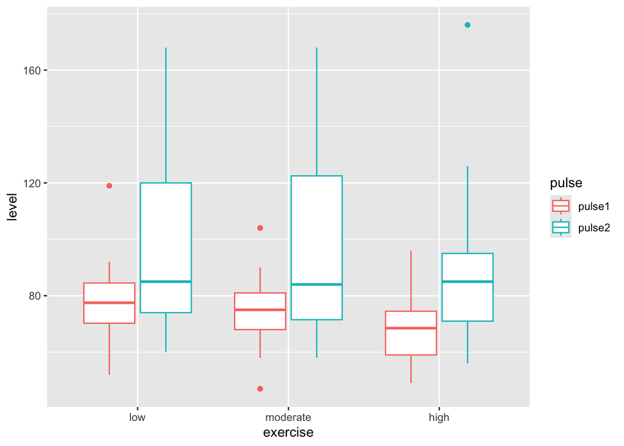

**Solution…**

```r
# 1)

survey <- read_csv("survey.csv", show_col_types = FALSE)
# 1.a)
survey |>
  count(gender,exercise) |>
  pivot_wider(names_from = exercise, values_from = n)
# 1.b)
survey |>
  count(gender,exercise) |>
  pivot_wider(names_from = gender, values_from = n)
# 1.c)
survey |>
  count(exercise,smokes) |>
  pivot_wider(names_from = exercise, values_from = n)

# 1.d)
# {gender, clap}, {gender, hand}, etc.



# 2
survey |>
  select(gender,fold,clap) |>
  pivot_longer(!gender, names_to = "action", values_to = "side") |>
  count(gender,side, name = "count") |>
  pivot_wider(names_from = "side",values_from = "count")

# 3
survey |>
  group_by(smokes, hand) |>
  summarise(size=n(), .groups = 'drop_last') |>
  mutate(percent=round(size/sum(size)*100,1) ) |>
  select(-size) |>
  pivot_wider(names_from = "hand", values_from = "percent")

# 4
ggplot(
        pulse |>
        drop_na() |>
        mutate(exercise=fct_relevel(exercise, c("low","moderate","high"))) |>
        pivot_longer(c(pulse1,pulse2), names_to = "pulse",values_to = "level")
      ) +  aes(x=exercise, y=level, color=pulse) + geom_boxplot()
```

## Real Data Analysis: Example data analysis problem (exercise) 📖

*Files:* rda-NL.rds, rda-UK.csv, rda-PL.tsv, rda-US.xlsx, rda-genes.csv.

### Task concept

This task demonstrates issues arising during analysis of real-world data.

We have artificially generated several tables with data and we introduced various problems in them. Identify the problems and decide how to handle them (e.g. correct, ignore, …).  
At the end of the course, the introduced problems will be discussed.

It is intentional, that the description is incomplete, and the task is not fully specified.  
Use your knowledge, creativity and search skills to solve the task.

### Example research question

Let’s assume that there are two simple research goals:

- Study the distribution of BMI in different populations.
- Find whether BMI is related to expression of some genes.

Several files with anthropometric data (known to be generated in different labs in different countries) are provided.  
Moreover, there is a file with gene expression data for some of the subjects from all countries.

Deliverables:

- A single, properly merged dataset containing all provided datasets (after cleaning and unification).
- A report demonstrating the properties of the data, the distributions of BMI in different populations and the relations of BMI to expressions of each of the genes.

Click the links above (after *Files:*), to download the data files.

### Organisation of files/directories

This task should be developed in a completely new RStudio project.

In the project directory:

- There should be a subdirectory called `data`:
  - All input files with data should be placed in this directory.
  - The files should never be modified in any way.
- It is convenient to have a subdirectory `outs`:
  - All automatically generated output files should be placed in this directory.
  - Separate directory allows easy removal of all generated files, in case of need.
- Provide an R Markdown script producing the report and generating the combined dataset.
- Provide a `README.md` file with a brief description of the project.

## Sampling age distribution and age categories (exercise) 📖

*Needs:* sample.  
*Gives:* cut, table, sample.  
*Practices:* c, barplot, names, sample, hist, quantile, cut, table.

From the [Eurostat database](https://ec.europa.eu/eurostat/web/population-demography/demography-population-stock-balance/database) we extracted estimated numbers of people of each age (range 0-99) living in the Netherlands at some recent timepoint:

```r
age2peopleNum <- c(
    168269, 170352, 170475, 172564, 175965, 175404, 180139, 176908, 181784,
    185590, 190635, 191482, 192005, 188439, 191716, 193571, 199395, 206526,
    212170, 220073, 227052, 223141, 222346, 217582, 217364, 218670, 225921,
    226586, 229437, 232336, 233373, 225765, 223129, 222512, 221707, 216407,
    212812, 206718, 207274, 210873, 213552, 206261, 206100, 203072, 204502,
    205704, 214821, 221789, 239466, 250796, 261082, 266183, 254782, 251611,
    252467, 255486, 259306, 254400, 248828, 245545, 237918, 234688, 227404,
    221405, 216249, 209604, 205025, 200158, 198908, 190078, 189246, 189135,
    192126, 198903, 201625, 140595, 143352, 132521, 118605, 108982, 107050,
    98198, 90976, 79680, 73223, 65613, 58404, 50597, 45188, 38009, 32204,
    25186, 20334, 15452, 11867, 8684, 6348, 4353, 2924, 1837
)
age2peopleNum[[1]]  # 168269 people of age 0-1
age2peopleNum[[2]]  # 170352 people of age 1-2, etc.
```

### Distribution

- Produce a barplot of the `age2peopleNum` distribution of the number of people by age.
- For better visualisation, add names to the vector `age2peopleNum`, so ages get visible in the barplot.

### Sampling

- Find how to use the `prob` argument of the `sample` function and generate a sample of 10000 ages from the distributed according to `age2peopleNum`. Store the sample in the variable `as`.
- Use `hist` to show the histogram of the generated ages. The shape should be similar to the barplot.
- What ages correspond to quantiles 0.1, 0.25, 0.5, 0.75, 0.9 of the sampled ages (hint: `quantile`)?

### Building age categories

- Find out how to use the `cut` function on sampled ages to create a factor with the following age categories: `infant` (age below 1), `child` (1<=age<10), `teenager` (10<=age<18), `adult` (18<=age<67), `senior` (67<=age). Store the factor in the variable `fs`.
- Use `table(fs, as)` to count the number of people in each category and age: double check whether the assigned categories are correct (consider `right=FALSE` argument to `cut`).

**Solution…**

```r
barplot( age2peopleNum )

ages <- 0:(length(age2peopleNum)-1)
names( age2peopleNum ) <- ages
barplot( age2peopleNum )

age2prob <- age2peopleNum / sum(age2peopleNum)
as <- sample( ages, size=10000L, replace=TRUE, prob=age2prob )
hist( as )
quantile( as, c(0.1, 0.25, 0.5, 0.75, 0.9) )

fs <- cut( as, breaks=c(0, 1, 10, 18, 67, 100), labels=c("infant", "child", "teenager", "adult", "senior"), right=FALSE )
table(fs, as)
```

## Grades report, set operations (exercise) 📖

*Needs:* “Vectors”.  
*Gives:* intersect, setdiff, union, “SetOperations”.  
*Practices:* c, mean, names, “[…]”, intersect, setdiff, union.

### Learn set operations

Study the following code to understand R set operations:

```r
x <- 1:4
y <- 3:6

intersect(x,y)        # element in all arguments
union(x,y)            # element in any argument
setdiff(x,y)          # element in x but not in y
setdiff(y,x)          # element in y but not in x
```

### Use set operations on named vectors

Alex has the following grades on several subjects:

```
|biology | 7.0|
|history | 6.0|
|math    | 9.0|
|music   | 7.5|
|physics | 8.0|
```

Hai, among other subjects, has taken similar subjects as Alex:

```
|biology   | 8.0|
|computing | 9.0|
|english   | 7.5|
|history   | 7.0|
|math      | 9.0|
```

Create the named numerical vectors `gradesAlex` and `gradesHai` from the tables above.

- Print both vectors (so the subjects and grades are visible).
- For each student what is the mean grade over subjects common to both?
- What subjects has Alex taken that Hai has not and vice versa?
- Show the distinct set of subjects taken by Alex and Hai.

**Solution…**

```r
gradesAlex <- c(biology=7.0, history=6.0, math=9.0, music=7.5, physics=8.0)
gradesHai  <- c(biology=8.0, computing=9.0, english=7.5, history=7.0, math=9.0)

gradesAlex
gradesHai

# Manually it could be done as follows:
common_subjects <- c("biology", "history", "math")
# But we prefer use of 'intersect':

common_subjects <- intersect(names(gradesAlex),names(gradesHai))
mean(gradesAlex[common_subjects])
mean(gradesHai[common_subjects])

setdiff(names(gradesAlex),names(gradesHai))
setdiff(names(gradesHai),names(gradesAlex))
union(names(gradesAlex),names(gradesHai))
```

# Data structures 2/2, Flow control

## Lists (lecture) 👩‍🏫

*Needs:* “Vectors”, length, str, names.  
*Gives:* “Lists”, list, “[[…]]”, names, length, str, “NULL”.

A **list** can be thought of as zero or more data elements (of *any type*), kept in order.  
The elements can be accessed by their **position** (or **index**): first element, second element, …  
Typically the elements are also named and consequently can be also accessed by the **names**.

A list allows to keep together related information.  
For example, functions often return lists when their result consists of many different parts.

### Create a list

Type the following code to **manualy create** a list and store it in a variable `person`:

```r
person <- list(
  name = "Bob",                        # character vector, length 1
  age = 44,                            # numeric vector, length 1
  children = c( "Amy", "Dan", "Eve" )  # character vector, length 3
)
person
```

```
$name
[1] "Bob"

$age
[1] 44

$children
[1] "Amy" "Dan" "Eve"
```

### List properties

The function `str` (**structure**) gives a compact display of data stored in a list:

```r
str( person )
```

```
List of 3
 $ name    : chr "Bob"
 $ age     : num 44
 $ children: chr [1:3] "Amy" "Dan" "Eve"
```

Use `length` to find the **number of elements** in a list:

```r
length( person )
```

```
[1] 3
```

To get the **names** of the elements of a list, use the `names` function:

```r
names( person )
```

```
[1] "name"     "age"      "children"
```

### Single element by position

An elements of a list can be accessed **by its position** (first, second, …) with help of `[[...]]` (double bracket) operator.  
Try the following to get the first and the last elements:

```r
person[[1]]
```

```
[1] "Bob"
```

```r
person[[ length(person) ]]
```

```
[1] "Amy" "Dan" "Eve"
```

You may also set the element by position:

```r
person[[1]] <- "Alice"
```

Observe, that the elements of the `person` list returned by `[[...]]` are of different classes:

```r
str( person[[1]] )
```

```
 chr "Alice"
```

```r
str( person[[2]] )
```

```
 num 44
```

### Single element by name

Each of the names can be used with the `[[...]]` operator to **get/set an element by name**:

```r
person[[ 'name' ]]
```

```
[1] "Alice"
```

```r
person[[ 'name' ]] <- "Hans-Peter"
person[[ 'name' ]]
```

```
[1] "Hans-Peter"
```

```r
person[[ 'children' ]]
```

```
[1] "Amy" "Dan" "Eve"
```

### Subsetting a list, many elements

Use the **single bracket** `[...]` operator to **subset** a list.  
Here, not an element is selected, but a new list is created with selected elements:

```r
person[ "name" ]                          # a list with one element
```

```
$name
[1] "Hans-Peter"
```

```r
selElems <- c( "name", "children" )
person[ selElems ]                        # a list with two elements
```

```
$name
[1] "Hans-Peter"

$children
[1] "Amy" "Dan" "Eve"
```

### Adding and removing elements

**Add a new element** as follow:

```r
person[[ 'smoker' ]] <- TRUE
person
```

```
$name
[1] "Hans-Peter"

$age
[1] 44

$children
[1] "Amy" "Dan" "Eve"

$smoker
[1] TRUE
```

Or, **change the element**:

```r
person[[ 'smoker' ]] <- FALSE
person
```

```
$name
[1] "Hans-Peter"

$age
[1] 44

$children
[1] "Amy" "Dan" "Eve"

$smoker
[1] FALSE
```

To **remove an element** from the list, assign `NULL` (nothing) to it:

```r
person[[ 'smoker' ]] <- NULL
person
```

```
$name
[1] "Hans-Peter"

$age
[1] 44

$children
[1] "Amy" "Dan" "Eve"
```

Note what happens when you try to access a **not present element**:

```r
person[[ 'isMarried' ]]
```

[output not shown]

## Grades of students (exercise) 📖

*Needs:* “Lists”, “Vectors”, NA, length, min, mean, “[…]”, “[[…]]”, “NULL”.  
*Practices:* length, “[…]”, “[[…]]”, min, mean, “NULL”, list.

There are four students: Alice, Bob, Charlie, and Daisy. Each student has several grades, and the number of grades is different for each student:

- Alice: 8, 9, 7.5, 8, 9
- Bob: 6, 7, 8, 7, 6, 5, 5, 8
- Charlie: 9, 7, 9
- Daisy: 8, ?, 6.5, 6.5, 7, 8, 7 (one grade is missing)

### Create and inspect the list

Build a list `grades` with the grades of the students, then inspect it:

- How many students are in the list?
- What are the names of the students?
- Retrieve Bob’s grades.
- How many grades does Charlie have?
- What are the mean grades of Bob and Daisy?
- What is Alice’s lowest grade?
- Alice and Daisy work in a group “A” and Bob and Charlie in a group “B”. Create separate lists for these groups in variables `groupA` and `groupB`.

**Solution…**

```r
grades <- list(
    Alice = c( 8, 9, 7.5, 8, 9 ),
    Bob = c( 6, 7, 8, 7, 6, 5, 5, 8 ),
    Charlie = c( 9, 7, 9 ),
    Daisy = c( 8, NA, 6.5, 6.5, 7, 8, 7 )
)

length(grades)
names(grades)
grades[['Bob']]
length(grades[['Charlie']])
mean(grades[['Bob']], na.rm=TRUE)
mean(grades[['Daisy']], na.rm=TRUE)
min(grades[['Alice']], na.rm=TRUE)
groupA <- grades[c('Alice', 'Daisy')]
groupB <- grades[c('Bob', 'Charlie')]
```

### Modify the list

- Add Eve with grades: 7.7, 8.5, 9.
- Add Charlie’s new grades: 8.5 and 9.
- Bob has moved to another school. Remove Bob.
- The missing grade of Daisy has been found. Replace the missing with the new grade 7.

**Solution…**

```r
grades[['Eve']] <- c(7.7, 8.5, 9)
grades[['Charlie']] <- c(grades[['Charlie']], 8.5,9)
grades[['Bob']] <- NULL
grades[['Daisy']][2] <- 7
```

## T-test returns a list (exercise) 📖

*Needs:* rnorm, mean, sd, “Lists”.  
*Gives:* t.test.  
*Practices:* rnorm, mean, sd, t.test, names.

The t-test is a statistical test used to determine if there is a significant difference between the means of two samples. (Here we will use the two-sample t-test, which is used to compare the means of two independent samples. There are some assumptions about the samples which must be met, but we do not discuss them here.)

### Generate two samples from the same normal distribution

- Generate two vectors `x` and `y` sampled from the same normal distribution (`rnorm` with the same mean and the same standard deviation). The vectors should have `n` elements each (`n=30`).
- Check the `mean` and `sd` (standard deviation) of the generated samples.

### Perform the t-test

- Find out how to use `t.test` to perform the t-test on the `x` and `y` vectors. Store the result in a variable `h`.
- The `t.test` function returns a list with the results of the test. Investigate the list (use `str` and/or `names`) and extract the difference `estimate` of the means and the `p.value`.
- Interpret the `p.value`. Since the `x` and `y` samples originate from the same distribution, in most cases the t-test should not reject the null hypothesis that the means are equal. Does the observed `p.value` confirm this?

### Repeat sampling and testing

- Repeat manually all steps several times. Will the `p.value` be always above 0.05 or you observe a **false positive**?

### Generate two samples from distributions with different means

- Finally, generate the `x` and `y` vectors with clearly different means (but the same standard deviation).
- Repeat the t-test. Is the result significant or you observe a **false negative**?

**Solution…**

```r
n <- 30
x <- rnorm( n = n, mean = 0, sd = 1 )
y <- rnorm( n = n, mean = 0, sd = 1 )
mean(x)
sd(x)
mean(y)
sd(y)

h <- t.test( x, y )
names(h)
h$estimate
h$p.value
```

## Matrices (lecture) 👨‍🏫

*Needs:* “Vectors”, length, str, names.  
*Gives:* “Matrices”, matrix, “[.,.]”, nrow, ncol, dim, colnames, rownames, rowMeans, rowSums, colMeans, colSums, t, “%*%“.

A **matrix** is a two-dimensional, rectangular structure with all elements of *the same type*.  
The elements can be accessed by their **two-dimensional position**: `[row, column]`.  
The rows and columns of the matrix might additionally be named and consequently can be also accessed by a pair `[rowname, colname]`.

### Create a matrix

A `matrix` can be **manually created** from a vector.  
Depending on the arguments, elements of the vector are put into the matrix in a different order (column-by-column or row-by-row):

```r
m <- matrix( 1:6, nrow = 2 )               # column-by-column
m
```

```
     [,1] [,2] [,3]
[1,]    1    3    5
[2,]    2    4    6
```

```r
m <- matrix( 1:6, nrow = 2, byrow = TRUE ) # row-by-row
m
```

```
     [,1] [,2] [,3]
[1,]    1    2    3
[2,]    4    5    6
```

Test the class of `m`:

```r
class( m )
```

```
[1] "matrix" "array"
```

Try the function `str` to get a compact summary of matrix content:

```r
str( m )
```

```
 int [1:2, 1:3] 1 4 2 5 3 6
```

### Dimensions

There are several functions to get dimensions of a matrix.

**Number of columns** is provided by:

```r
ncol( m )
```

```
[1] 3
```

**Number of rows** is provided by:

```r
nrow( m )
```

```
[1] 2
```

**Dimensions** (two elements: number of rows and number of columns):

```r
dim( m )
```

```
[1] 2 3
```

### Names of the columns and rows

`colnames( m )` and `rownames( m )` are used to set and get the vectors with columns and rows names.

Try to **set the names**:

```r
m <- matrix( 1:6, nrow = 3 )
m
```

```
     [,1] [,2]
[1,]    1    4
[2,]    2    5
[3,]    3    6
```

```r
colnames( m ) <- c( "A", "B" )
m
```

```
     A B
[1,] 1 4
[2,] 2 5
[3,] 3 6
```

```r
rownames( m ) <- c( "X", "Y", "Z" )
m
```

```
  A B
X 1 4
Y 2 5
Z 3 6
```

To **get the names** use:

```r
rownames( m )
```

```
[1] "X" "Y" "Z"
```

```r
colnames( m )
```

```
[1] "A" "B"
```

### Accessing matrix elements

Use single brackets notation with two arguments `[ row(s), col(s) ]` to **get/set elements**.  
Note, when getting only a single row or a single column the result is *returned as a vector, not as a matrix*.

```r
m[ 3, 1 ]             # a single element as a vector of length 1
```

```
[1] 3
```

```r
m[ 3, ]               # a single row as a vector
```

```
A B
3 6
```

```r
m[ , 1 ]              # a single column as a vector
```

```
X Y Z
1 2 3
```

```r
m[ c( 2, 3 ), 1 ]     # two rows/one column, still a vector
```

```
Y Z
2 3
```

```r
m[ c( 2, 3 ), c( "B", "A" ) ]     # a matrix 2x2
```

```
  B A
Y 5 2
Z 6 3
```

```r
m[ c( F, T, T ), c( "B", "A" ) ]  # a matrix 2x2 (rows 2 and 3 corresponding to TRUE)
```

```
  B A
Y 5 2
Z 6 3
```

Notice the difference in the output class when only a single element is requested:

```r
class( m[ 3, 1 ] )
```

```
[1] "integer"
```

```r
class( m[ c( 2, 3 ), c( "B", "A" ) ] )
```

```
[1] "matrix" "array"
```

With the `drop` argument you may enforce that always a matrix is returned (never a vector):

```r
m[ 3, 1 ]                 # a vector
```

```
[1] 3
```

```r
m[ 3, 1, drop = FALSE ]   # a matrix
```

```
  A
Z 3
```

```r
class( m[ 3, 1, drop = FALSE ] )
```

```
[1] "matrix" "array"
```

Empty row/column argument field means **all rows** and/or **all columns**:

```r
m[ , c( "B", "A" ) ]       # all rows, selected columns
```

```
  B A
X 4 1
Y 5 2
Z 6 3
```

```r
m[ c( "Z", "X", "Y" ), ]   # selected rows, all columns
```

```
  A B
Z 3 6
X 1 4
Y 2 5
```

```r
m[ , ]                     # all rows and columns, same as just "m"
```

```
  A B
X 1 4
Y 2 5
Z 3 6
```

### Useful matrix functions

Short summary of matrix operations: http://www.statmethods.net/advstats/matrix.html

#### Transposition

```r
m <- matrix( 1:6, nrow = 3 )
colnames( m ) <- c( "A", "B" )
rownames( m ) <- c( "X", "Y", "Z" )
m
```

```
  A B
X 1 4
Y 2 5
Z 3 6
```

```r
t(m)
```

```
  X Y Z
A 1 2 3
B 4 5 6
```

#### Matrix multiplication

```r
m
```

```
  A B
X 1 4
Y 2 5
Z 3 6
```

```r
t( m )
```

```
  X Y Z
A 1 2 3
B 4 5 6
```

```r
m %*% t( m )
```

```
   X  Y  Z
X 17 22 27
Y 22 29 36
Z 27 36 45
```

#### Element-wise multiplication

```r
m
```

```
  A B
X 1 4
Y 2 5
Z 3 6
```

```r
m+1
```

```
  A B
X 2 5
Y 3 6
Z 4 7
```

```r
m * (m+1)
```

```
   A  B
X  2 20
Y  6 30
Z 12 42
```

#### Row/columns means/sums

```r
m
```

```
  A B
X 1 4
Y 2 5
Z 3 6
```

```r
rowMeans( m )
```

```
  X   Y   Z
2.5 3.5 4.5
```

```r
rowSums( m )
```

```
X Y Z
5 7 9
```

```r
colMeans( m )
```

```
A B
2 5
```

```r
colSums( m )
```

```
 A  B
 6 15
```

## Correlation heatmaps (exercise) 📖

*Needs:* “Matrices”.  
*Gives:* cor, cbind, heatmap.  
*Practices:* rnorm, cor, cbind, heatmap.

### Correlated vectors

Let’s define a parameter `size <- 12`. Later this will be the number of rows of the matrix.  
From the normal distribution let’s sample a random vector: `x <- rnorm( size )`.  
Now, let’s create another vector `x1` by adding some noise to `x`: `x1 <- x + rnorm( size )/10`.  
The noise is “small”, so the correlation coefficient of `x` and `x1` should be close to 1.0: check this with function `cor`.  
Finally, in a similar way create vectors `x2` and `x3` by adding (other) small noise to `x`.

**Solution…**

```r
size <- 12
x <- rnorm( size )
x1 <- x + rnorm( size )/10
cor( x, x1 )
x2 <- x + rnorm( size )/10
x3 <- x + rnorm( size )/10
```

### Matrix from vectors; matrix heatmap

Let’s merge `x1`, `x2` and `x3` column-wise into a matrix using `m <- cbind( x1, x2, x3 )`.  
Check the class of `m`.  
Show the first few rows of `m`.  
Try a simple heatmap visualisation of the matrix: `heatmap( m, Colv = NA, Rowv = NA, scale = "none" )`.  
How are the vectors shown?  
Which colors correspond to the lowest/highest matrix values?  
Do the vectors appear correlated?

**Solution…**

```r
m <- cbind( x1, x2, x3 )
class( m )
head( m )
heatmap( m, Colv = NA, Rowv = NA, scale = "none" ) # high is dark red, low is yellow
                # x1, x2, x3 follow similar color pattern, they should be correlated
```

### Matrix of correlated and uncorrelated vectors

Repeat the first exercise and create several other vectors `y1`…`y4` correlated to each other, but not correlated with `x`.  
Each vector should have the same length `size`.  
Now build again `m` from the columns `x1`…`x3`,`y1`…`y4` (in some random order).  
Show again the heatmap; you should see similarity between some columns.

**Solution…**

```r
y <- rnorm( size )
y1 <- y + rnorm( size )/10
y2 <- y + rnorm( size )/10
y3 <- y + rnorm( size )/10
y4 <- y + rnorm( size )/10
m <- cbind( y4, y3, x2, y1, x1, x3, y2 )
heatmap( m, Colv = NA, Rowv = NA, scale = "none" ) # high is dark red, low is yellow
```

### Matrix of correlations

Use `cc <- cor( m )` to build the matrix of correlation coefficients between the columns of `m`.  
Use `round( cc, 3 )` to show this matrix with 3 digits precision.  
Can you interpret the values?

**Solution…**

```r
cc <- cor( m )
round( cc, 3 )
```

Here is an example, how the heatmap of correlations could look like (of course, for your randomly sampled data it will look slighly different):

**Solution…**

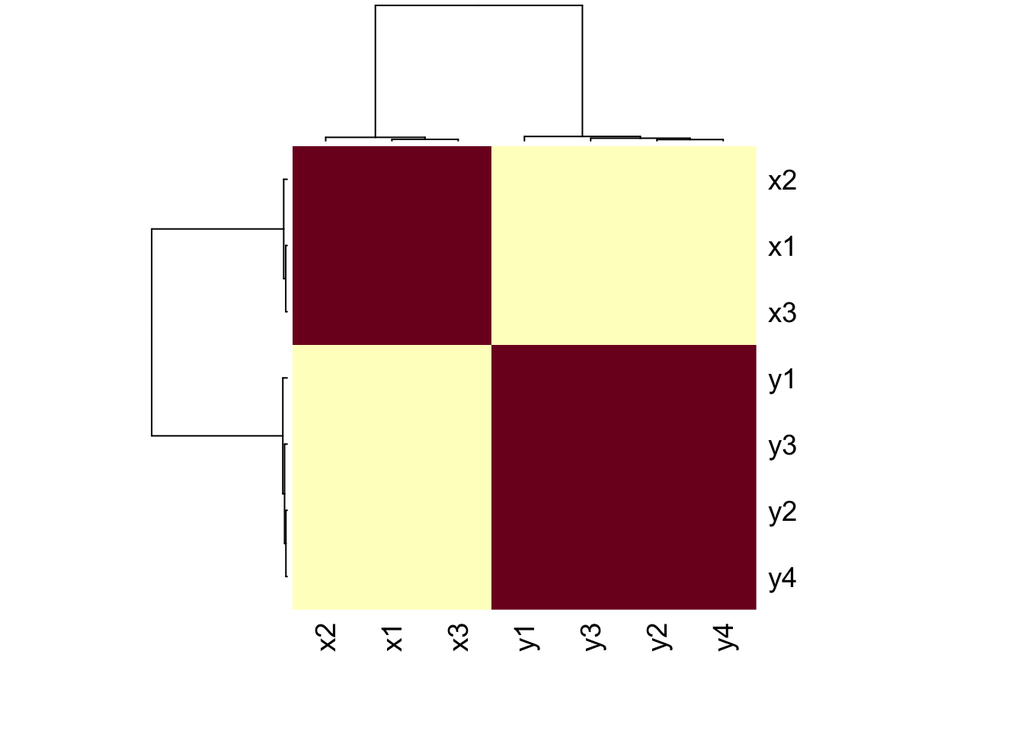

```r
size <- 12

# --- x and y have correlation around 0 ---
x <- rnorm( size )
y <- rnorm( size )

# --- x1, x2, x3 are correlated to each other ---
x1 <- x + rnorm( size )/10
x2 <- x + rnorm( size )/10
x3 <- x + rnorm( size )/10

# --- y1...y4 are correlated to each other ---
y1 <- y + rnorm( size )/10
y2 <- y + rnorm( size )/10
y3 <- y + rnorm( size )/10
y4 <- y + rnorm( size )/10

# --- matrix of all vectors ---
m <- cbind( y4, y3, x2, y1, x1, x3, y2 )

# --- calculating correlations of all matrix column pairs ---
cc <- cor( m )

# --- visualisation of correlations ---
heatmap( cc, symm = TRUE, scale = "none" )
```

**Solution…**

```r
# E.g. value for (row: x1, col: y1) is the corerlation of vectors x1, y1.
# Values of 1.0 are on the diagonal: e.g. x1 is perfectly correlated with x1.
# Correlations between x, x vectors are close to 1.0.
# Correlations between y, y vectors are close to 1.0.
# Correlations between x, y vectors are close to 0.0.
```

## Modelling weight from height, linear model (exercise) 📖

*Needs:* “pulseNA.csv”.  
*Gives:* lm, summary, “Formulas”, plot, abline, “~”.  
*Practices:* lm, summary, plot, abline, names, “~”.

### Formula objects

Let’s assume that it is acceptable to use a linear model to model the weight of a person based on their height. R uses the **formula** notation to express the relationship between variables: `weight ~ height`. The formula is an abstract representation of the relationship between the variables. No calculations are performed at this stage.

```r
height ~ weight           # height depends on weight
```

```
height ~ weight
```

```r
height ~ weight + gender  # height depends on weight and gender
```

```
height ~ weight + gender
```

```r
form <- weight ~ height   # formulas are objects; can be stored in variables
form
```

```
weight ~ height
```

### Fitting a linear model: weight ~ height

- Load the `pulseNA.csv` dataset.
- Plot the `weight` against the `height` using the `plot` function.
- Fit out how to fit a linear model to the data with the `lm` function. Use the formula `weight ~ height`. Store the result in a variable `h`. Observe what is printed when you print the `h` object.
- Use the `summary` function to get a further summary of the linear model. Store the result in a variable `sumH`. Print it.
- Plot again, use `plot( weight ~ height, data = d ) + abline(h, col="red")`.
- Treat `sumH` as a list and find out what are the names of the elements of the `sumH` object. Print the `coefficients` and `adj.r.squared` elements. Compare their values with the printed output of `h` and `sumH`.
- Can you interpret the result?

**Solution…**

```r
d <- read.csv( "pulseNA.csv" )
form <- weight ~ height
plot( form, data = d ) # formula notation is also allowed here
h <- lm( form, data = d )
plot( weight ~ height, data = d ) + abline(h, col="red")
h
sumH <- summary(h)
sumH
names(sumH)
sumH$coefficients
sumH$adj.r.squared
```

## Flow control: `if`/`else`, `for` (lecture) 👩‍🏫

*Needs:* “Vectors”, sample, intersect, names, sort.  
*Gives:* “if”, “else”, “for”, “break”, “next”, seq_along, seq_len.

### Conditional execution: `if`, `else`

The `if` statement allows to execute a block of code only if a condition is met. After `if` there can be an optional `else` statement with another block of code to execute if the `if` condition has not been met.

Let’s consider a simple example of a lottery bet:

```r
myBet <- c( 1, 24, 26, 32, 36, 40 )               # 6 numbers from 1 to 45
lotteryDraw <- sort( sample( 1:45, 6 ) )          # lottery draw
lotteryDraw
```

```
[1]  1 10 18 25 36 37
```

```r
intersect( myBet, lotteryDraw )                   # matched numbers
```

```
[1]  1 36
```

```r
num <- length( intersect( myBet, lotteryDraw ) )  # number of matched numbers
num
```

```
[1] 2
```

The following code prints some text only if at least one number matched:

```r
if( num > 0 ) {
  print( "You matched at least one!" )
}
```

```
[1] "You matched at least one!"
```

Additionally, a different text is printed if no number matched:

```r
if( num == 0 ) {
  print( "You lost!" )
} else {
  print( "You matched at least one!" )
}
```

```
[1] "You matched at least one!"
```

The following code prints different text depending on the number of matched numbers:

```r
if( num >= 3 ) {
  print( "WOW, you matched at least three!" )
} else if( num == 0 ) {
  print( "You lost!" )
} else {
  print( "There is a match, but of low value." )
}
```

```
[1] "There is a match, but of low value."
```

### Looping: `for`

A **for loop** repeats a block of code for each element of an iterable object (e.g. vector or list), in the same order.

A typical use-case is to loop over elements of a vector (or a list):

```r
vs <- c( a=37, b=44, c=21, d=63, e=15 )

sum <- 0
for( v in vs ) {            # loop over elements of vs; works always
  sum <- sum + v            # exectued many times for v being each element of vs
}
sum
```

```
[1] 180
```

Another way is to loop over indices of a vector (or a list). Use `seq_along` to get a sequence of indices (it works correctly for the empty vector/list):

```r
sum <- 0
for( i in seq_along(vs) ) { # loop over indices of vs; works always
  sum <- sum + vs[[i]]      # executed many times for i being each index of vs
}
sum
```

```
[1] 180
```

For objects with named elements, it is possible to loop over names:

```r
sum <- 0
for( n in names(vs) ) {     # loop over names of vs elements; fails if no names
  sum <- sum + vs[[n]]      # executed many times for n being each name of vs
}
sum
```

```
[1] 180
```

To simply repeat a block of code a fixed number of times, use `seq_len`:

```r
repeatNum <- 4              # seq_len(4) is c(1,2,3,4), seq_len(0) is empty
for( i in seq_len(repeatNum) ) {
  print( i )                # 1:4 id c(1,2,3,4), but 1:0 is NOT empty!
}
```

```
[1] 1
[1] 2
[1] 3
[1] 4
```

A loop might be broken with the `break` statement:

```r
vs <- c( 18, 33, NA, 61 )
anyMissing <- FALSE
for ( v in vs ) {
  if( is.na(v) ) {
    anyMissing <- TRUE
    print( "Missing found" )
    break
  }
  print( v )
}
```

```
[1] 18
[1] 33
[1] "Missing found"
```

```r
anyMissing
```

```
[1] TRUE
```

To skip the rest of the loop and continue with the next iteration, use the `next` statement:

```r
vs <- c( 18, 33, -1, 61, -1 )
for ( v in vs ) {
  if( v < 0 ) {
    print( "Not printing negatives" )
    next
  }
  print( v )
}
```

```
[1] 18
[1] 33
[1] "Not printing negatives"
[1] 61
[1] "Not printing negatives"
```

## Flow control: functions (lecture) 👩‍🏫

*Needs:* “if”, “else”, sum, exp, 🔴log, length.  
*Gives:* “function”, return, stopifnot, all.equal.

### Function definition

**Functions** allow to encapsulate a block of code and execute (**call**) it multiple times. The name of the function allows to represent the block of code with a single word. The **arguments** of the function allow to pass different values to the block of code. The **return value** of the function allows to pass a single value back to the caller.

```r
ageGroup <- function(age) { # define function `ageGroup`, one argument `age`
  if( age < 18 ) {          # function body...
    return( "child" )       #     ...return text "child" if age is less than 18
  } else if( age < 65 ) {
    return( "adult" )       #     ...return text "adult" if age is less than 65
  } else {
    return( "senior" )      #     ...return text "senior" otherwise
  }                         # ...end of function body
}

ageGroup( 12 )              # call function `ageGroup` with first argument 12
```

```
[1] "child"
```

```r
ageGroup( age=35 )          # call function `ageGroup` with `age` argument 35
```

```
[1] "adult"
```

### Testing functions

When we develop a function, we always first test it. The `stopifnot` function allows to replace manual testing and save the tests for future (when potentially the function gets incorectly modified). The `stopifnot` function produces an error if the expression in its argument is not `TRUE`:

```r
stopifnot( ageGroup( 12 ) == "child" )
stopifnot( ageGroup( age=35 ) == "adult" )
# stopifnot( ageGroup( age=35 ) == "ADULT" )   # test to see the error message
```

### Default arguments

A function might have **default arguments**. The caller can omit the value of a default argument, and the default value will be used instead. Let’s define our own function to calculate the mean of a vector of numbers. The function will have an argument `isGeometric` to allow to calculate the geometric mean instead of the algebraic mean:

```r
myMean <- function( vs, isGeometric=FALSE ) {
  if( isGeometric ) {
    res <- exp( sum(log(vs)) / length(vs) )
  } else {
    res <- sum(vs)/length(vs)
  }
  res
}

myMean( vs=c(2,4,8), isGeometric=FALSE )      # algebraic mean
```

```
[1] 4.666667
```

```r
myMean( vs=c(2,4,8), isGeometric=TRUE )       # geometric mean
```

```
[1] 4
```

```r
myMean( vs=c(2,4,8) )                         # algebraic mean, default arg
```

```
[1] 4.666667
```

```r
myMean( c(2,4,8), TRUE )                      # arguments matched by position
```

```
[1] 4
```

```r
myMean( isGeometric=TRUE, vs=c(2,4,8) )       # arguments matched by name
```

```
[1] 4
```

When writing tests for equality of numerical results, it is better to use `all.equal` (close numerical result up to a certain tolerance) instead of `==` (exact equality):

```r
stopifnot( myMean( c(1,2,3,4,5) ) == 3 )        # works well
#stopifnot( myMean( c(1,10,100), TRUE ) == 10 ) # fails, precision problem
stopifnot( all.equal( myMean( c(1,10,100), TRUE ), 10 ) ) # works well
```

## Printing patterns (exercise) 📖

*Needs:* “for”, “if”, “else”, seq_len.  
*Gives:* cat, stop.  
*Practices:* “for”, “if”, “else”, cat, stop.

Understand, how the following code draws a rectangle from `*` symbols:

```r
rowsNum <- 4
colsNum <- 15
fillChar <- "*"
for( r in seq_len(rowsNum) ) {
  for( c in seq_len(colsNum) ) {
    cat( fillChar )                 # prints a single character
  }
  cat( "\n" )                       # prints a newline character
}
```

### Encapsulate the code in a function

Define a function `catFilledRect`. The function should print a rectangle as shown above. The size of the rectangle should be provided as function arguments `rowsNum` and `colsNum`. The fill character should be provided as the third argument `fillChar` (with a default value of `*`).

Below you can see some examples of the expected output.

**Solution…**

```r
catFilledRect <- function( rowsNum, colsNum, fillChar="*" ) {
  for( r in seq_len(rowsNum) ) {
    for( c in seq_len(colsNum) ) {
      cat( fillChar )
    }
    cat( "\n" )
  }
}
```

```r
catFilledRect( rowsNum=3, colsNum=15, fillChar="X" )
```

```
XXXXXXXXXXXXXXX
XXXXXXXXXXXXXXX
XXXXXXXXXXXXXXX
```

```r
catFilledRect( 4, 2 )
```

[output not shown]

### Reuse one function in another

Write a function `catSquare` that prints a square of a given size. The function should use the `catFilledRect` function with appropriate arguments.

The function should work as follows:

**Solution…**

```r
catSquare <- function( size, fillChar="*" ) {
  catFilledRect( rowsNum=size, colsNum=size, fillChar=fillChar )
}
```

```r
catSquare( size=4, fillChar="X" )    # prints 4x4 square filled with X
```

```
XXXX
XXXX
XXXX
XXXX
```

```r
catSquare( size=2 )                  # prints 2x2 square filled with *
```

[output not shown]

### Add an error stop for nonsense arguments

Find out how to use `stop` to produce an error when a negative size is provided. Rewrite `catSquare` to produce the error as follows:

**Solution…**

```r
catSquare <- function( size, fillChar="*" ) {
  if( size < 0 ) {
    stop( "Size must be non-negative!" )
  }
  catFilledRect( rowsNum=size, colsNum=size, fillChar=fillChar )
}
```

```r
catSquare( size=-1, fillChar="X" )     # we print an own error for size < 0
```

```
Error in catSquare(size = -1, fillChar = "X"): Size must be non-negative!
```

### Different shapes

Implement functions `catRect`, `catBackslash`, `catSlash`, and `catX` based on the examples shown below. The functions should print the shapes as shown. You may throw errors when arguments make no sense (not shown in the solutions).

**Solution…**

```r
catRect <- function( rowsNum, colsNum, drawChar="*", fillChar="." ) {
  for( r in seq_len(rowsNum) ) {
    for( c in seq_len(colsNum) ) {
      if( r == 1 || r == rowsNum || c == 1 || c == colsNum ) {
        cat( drawChar )
      } else {
        cat( fillChar )
      }
    }
    cat( "\n" )
  }
}
```

```r
catRect( rowsNum=5, colsNum=15, drawChar="*", fillChar="." )
```

```
***************
*.............*
*.............*
*.............*
***************
```

**Solution…**

```r
catBackslash <- function( size, drawChar="*", fillChar="." ) {
  for( r in seq_len(size) ) {
    for( c in seq_len(size) ) {
      if( r == c ) {
        cat( drawChar )
      } else {
        cat( fillChar )
      }
    }
    cat( "\n" )
  }
}
```

```r
catBackslash( size=6, drawChar="*", fillChar="." )
```

```
*.....
.*....
..*...
...*..
....*.
.....*
```

**Solution…**

```r
catSlash <- function( size, drawChar="*", fillChar="." ) {
  for( r in seq_len(size) ) {
    for( c in seq_len(size) ) {
      if( r == size-c+1 ) {
        cat( drawChar )
      } else {
        cat( fillChar )
      }
    }
    cat( "\n" )
  }
}
```

```r
catSlash( size=8, drawChar="*", fillChar="." )
```

```
.......*
......*.
.....*..
....*...
...*....
..*.....
.*......
*.......
```

**Solution…**

```r
catX <- function( size, drawChar="*", fillChar="." ) {
  for( r in seq_len(size) ) {
    for( c in seq_len(size) ) {
      if( r == size-c+1 || r ==c ) {
        cat( drawChar )
      } else {
        cat( fillChar )
      }
    }
    cat( "\n" )
  }
}
```

```r
catX( size=8, drawChar="*", fillChar="." )
```

```
*......*
.*....*.
..*..*..
...**...
...**...
..*..*..
.*....*.
*......*
```

# Graphics

## Introduction to `ggplot2` (lecture) 👩‍🏫

*Files:* pulseNA.csv.  
*Needs:* “tidyverse”, read_csv, “pulseNA.csv”, “|>”.  
*Gives:* “ggplot2”, ggplot, geom_point, aes, drop_na.

The [`ggplot2` package](https://ggplot2.tidyverse.org/) (a part of the `tidyverse` library) is a powerful tool for creating visualizations in R. The package provides the **grammar of graphics** and allows to create complex plots with a simple syntax.  
The main input is a `tibble` with the data to be plotted, and the main function is `ggplot`. A plot is built by adding layers to the plot object.

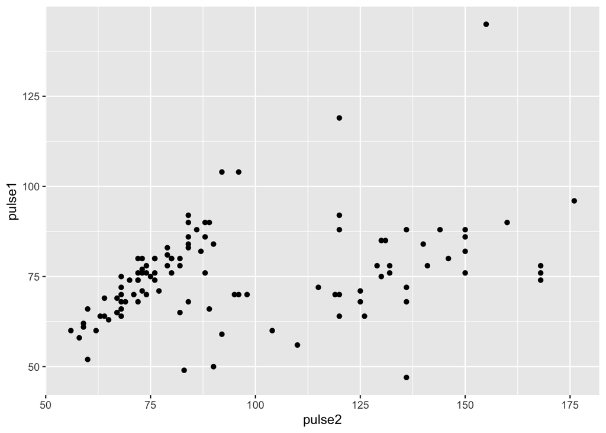

```r
library(tidyverse)
d <- read_csv( "pulseNA.csv" , show_col_types = FALSE )

plotData <- d |> drop_na( pulse1, pulse2, gender )
ggplot(plotData) +
  geom_point( aes(x=pulse2, y=pulse1) )
```

The layer provided by `geom_point` is used to create a scatter plot. Points in a scatter plot have coordinates given by the `x` and `y` aesthetics. Moreover, the points have `color`, `shape`, and `size` aesthetics. When an aesthetic is listed in the `aes` function, it refers to a column of the table. When it is listed outside of the `aes` function, it is a constant value.

Below, the `x` and `y` aesthetics are taken from the `pulse1` and `pulse2` columns of the table, whereas the `color` aesthetic is set to a constant `darkgreen` (see help for the function `colors` for other colors).

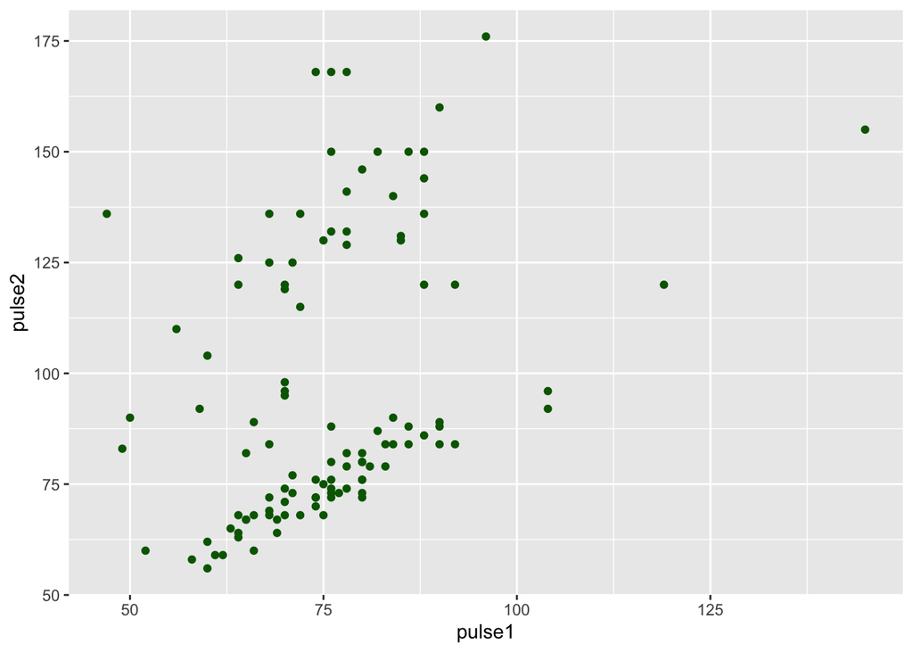

```r
ggplot(plotData) +
  geom_point( aes(x=pulse1, y=pulse2), color="darkgreen" )
```

Below, the `color` aesthetic uses the `ran` column of the table. Some colors are automatically chosen to represent the levels of the `ran` column:

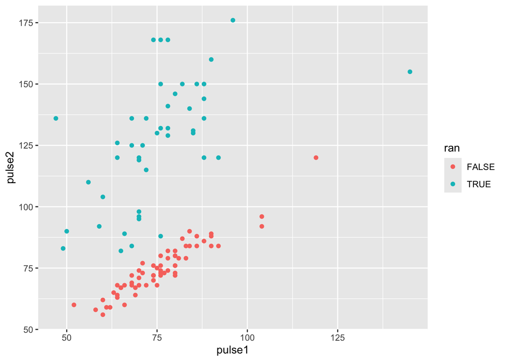

```r
ggplot(plotData) +
  geom_point( aes(x=pulse1, y=pulse2, color=ran) )
```

The `size`, `shape`, `alpha` (transparency level in 0..1 range) are other available aesthetics (see [Aesthetic specifications](https://ggplot2.tidyverse.org/articles/ggplot2-specs.html)).

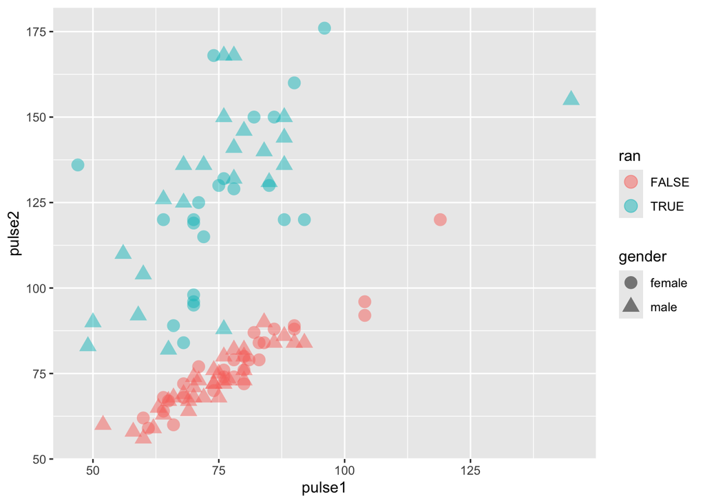

```r
ggplot(plotData) +
  geom_point( aes(x=pulse1, y=pulse2, color=ran, shape=gender), size=4, alpha=0.5 )
```

## Customizing plot axes, colors, scales and dimensions (exercise) 📖

*Files:* pulseNA.csv.  
*Needs:* “tidyverse”, “pulseNA.csv”, ggplot, geom_point, aes, “|>”, drop_na.  
*Gives:* scale_color_manual, scale_shape_manual, xlab, ylab, ggsave, scale_color_continuous, scale_size_area, scale_x_continuous, scale_y_continuous, coord_fixed, geom_abline.  
*Practices:* ggplot, aes, scale_color_manual, scale_shape_manual, xlab, ylab, ggsave, scale_color_continuous, scale_size_area, scale_x_continuous, scale_y_continuous, coord_fixed, geom_abline.

### Categorical variables used for color and shape; axes labels

Start with a plot defined in the variable `p` as follows:

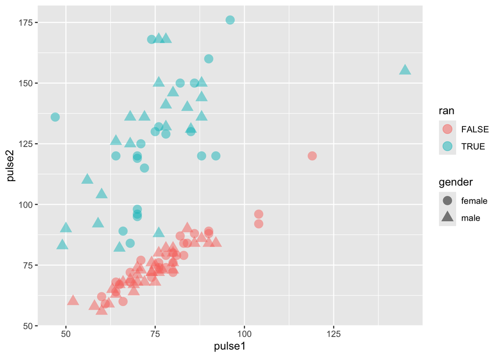

```r
suppressPackageStartupMessages( library(tidyverse) )

plotData <- read_csv( "pulseNA.csv" , show_col_types = FALSE ) |>
  drop_na( pulse1, pulse2, gender )
p <- ggplot(plotData) +
  geom_point( aes(x=pulse1, y=pulse2, color=ran, shape=gender), size=4, alpha=0.5 )
p
```

Find, what needs to be further added to `p` to obtain the plot shown below:

- The functions `scale_color_manual` and `scale_shape_manual` allow to customize the colors and shapes of the points used in the plot, when data is categorical. Their `values` argument is a named vector allowing to manualy enumerate shapes or colors (e.g. `c("TRUE"="red", ...)`). The `name` argument allows to specify the legend title (use `\n` to insert a line break).
- The functions `xlab` and `ylab` allow to set the labels of the x and y axes.

**Solution…**

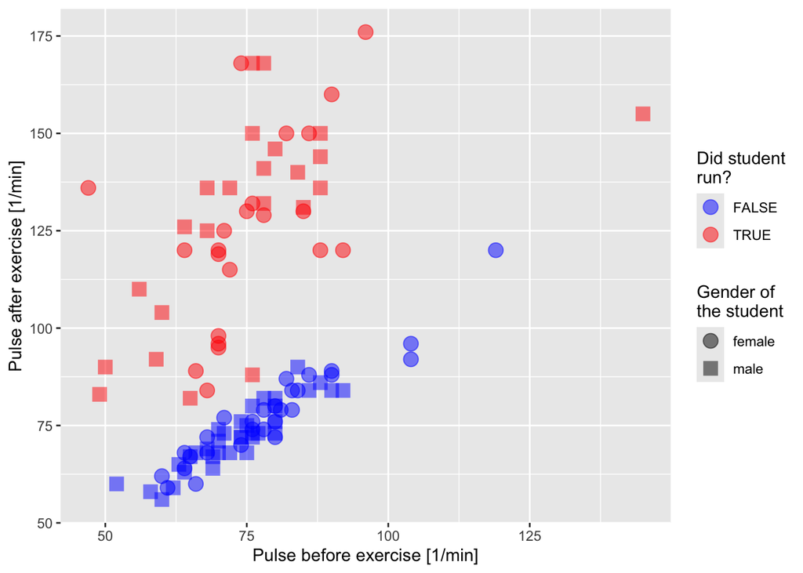

```r
p <- p +
  scale_color_manual( values=c("TRUE"="red", "FALSE"="blue"), name="Did student\nrun?" ) +
  scale_shape_manual( values=c("female"=19, "male"=15), name="Gender of\nthe student" ) +
  xlab("Pulse before exercise [1/min]") +
  ylab("Pulse after exercise [1/min]")
p
```

### Continuous variables used for color, size, axes

Now, start with a different plot:

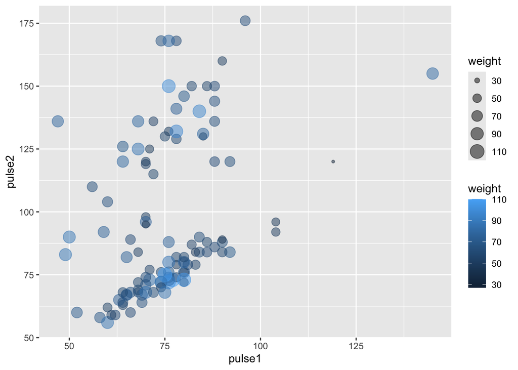

```r
p <- ggplot(plotData) +
  geom_point( aes(x=pulse1, y=pulse2, color=weight, size=weight), alpha=0.5 )
p
```

Find, what needs to be further added to `p` to obtain the plot shown below:

- The function `scale_color_continuous` allow to customize the colors representing a continuous variable. The `low` and `high` arguments specify the colors for the smallest and the largest values of the variable.
- The function `scale_size_area` allows to customize the sizes of the points representing a non-negative continuous variable. The `max_size` argument specifies the size of the largest point.
- The functions `scale_x_continuous` and `scale_y_continuous` allow to specify more details of x and y axes. The `name` argument specifies the title of the axis. The `breaks` argument specifies the positions of the ticks on the axis.
- The function `coord_fixed` enforces the same physical size of a unit on both axes. This is useful, when the units of the x and y axes are the same.
- The `geom_abline(slope=1)` function adds a diagonal line to the plot. Other arguments allow to specify the `color` and `type` of the line.

**Solution…**

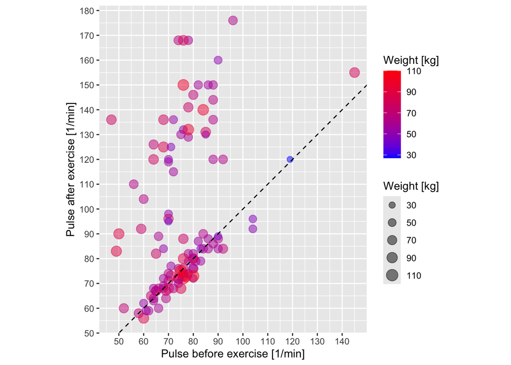

```r
brks <- seq(40,180,10)
p <- p +
  geom_abline( slope=1, intercept=0, color="black", linetype="dashed" ) +
  scale_color_continuous( low="blue", high="red", name="Weight [kg]" ) +
  scale_size_area( name="Weight [kg]", max_size=5 ) +
  scale_x_continuous(name="Pulse before exercise [1/min]", breaks=brks) +
  scale_y_continuous(name="Pulse after exercise [1/min]", breaks=brks) +
  coord_fixed()
p
```

### Saving the plot to a file, changing dimensions

Given the plot in the variable `p`, find out how to use `ggsave` to save the plot to a file in a `png` format. Try to save the plot in two different image sizes.

**Solution…**

```r
ggsave( filename="plot1.png", plot=p, width=6, height=4 ) # png format, small
ggsave( "plot2.png", p, width=8, height=6 )               # png, larger
ggsave( filename="plot3.eps", plot=p, width=6, height=4 ) # different format
```

Moreover, find out what parameters of an R chunk need to be set in order to change the plot size when the plot is knitted. For example like here:

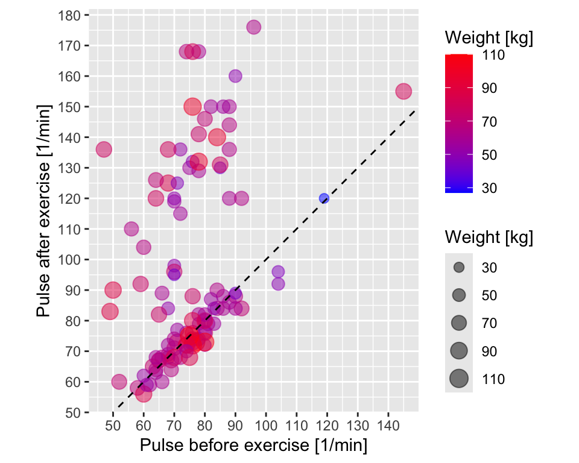

**Solution…**

```r
# {r fig.width=5,fig.height=4} are the parameters of the R chunk used here
p
```

## Plot types: histogram, boxplot, barplot (exercise) 📖

*Files:* pulseNA.csv.  
*Needs:* “tidyverse”, “pulseNA.csv”, ggplot, geom_point, aes, factor, ylab.  
*Gives:* geom_histogram, geom_boxplot, geom_bar, ggtitle, scale_x_continuous, geom_jitter, theme_dark, ylab, theme_bw.  
*Practices:* ggplot, aes, geom_histogram, geom_boxplot, geom_bar, ggtitle, scale_x_continuous, geom_jitter, theme_dark, theme_bw, drop_na, ylab, factor.

### Loading the data

Load the dataset as follows. Then find out how to recreate the following plots. Pay attention to the details. The solutions should include the functions/arguments/words listed at each point.

```r
suppressPackageStartupMessages( library(tidyverse) )
plotData <- read_csv( "pulseNA.csv" , show_col_types = FALSE)
```

### Histogram

In your solution use (among others): `drop_na`, `geom_histogram`, `binwidth`, `boundary`, `fill`, `color`, `ggtitle`, `scale_x_continuous`, `breaks`, `seq`, `name`. There should be no warning message.

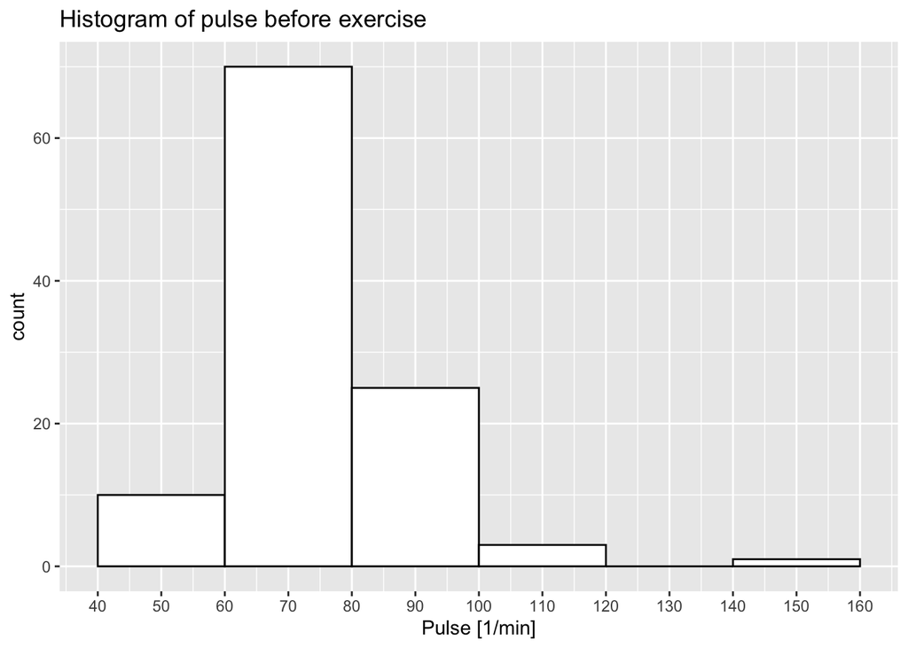

**Solution…**

```r
p <- ggplot(
    plotData |> drop_na( pulse1 )
  ) +
  geom_histogram(
    aes(x=pulse1),
    binwidth=20, boundary=80, fill="white", color="black"
  ) +
  ggtitle( "Histogram of pulse before exercise" ) +
  scale_x_continuous( breaks=seq(40,200,10), name="Pulse [1/min]" )
p
```

### Boxplot

Use: `geom_boxplot`, `geom_jitter`, `outlier.color`, `theme_dark`, `ylab`.

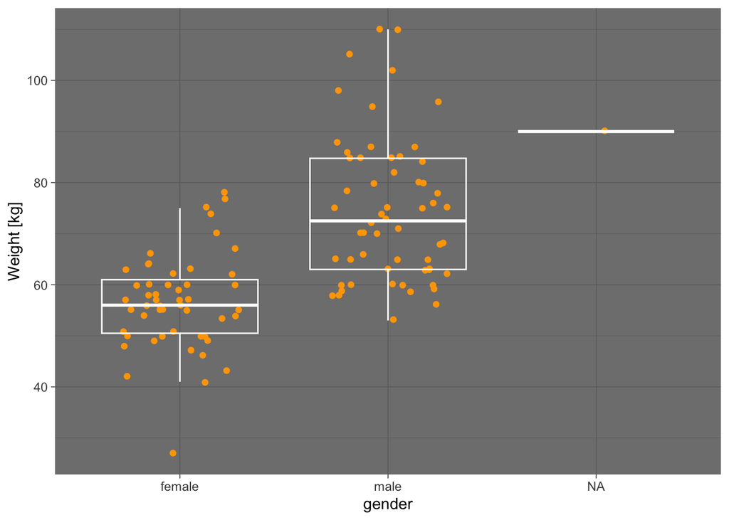

**Solution…**

```r
p <- ggplot(plotData) +
  aes( x = gender, y = weight ) +
  geom_jitter( width=0.3, color = "orange" ) +
  geom_boxplot( fill=NA, color="white", outlier.color=NA ) +
  theme_dark() +
  ylab( "Weight [kg]" )
p
```

### Barplot

Use: `mutate`, `factor`, `levels`, `geom_bar`, `fill`, `color`, `alpha`, `theme_bw`.

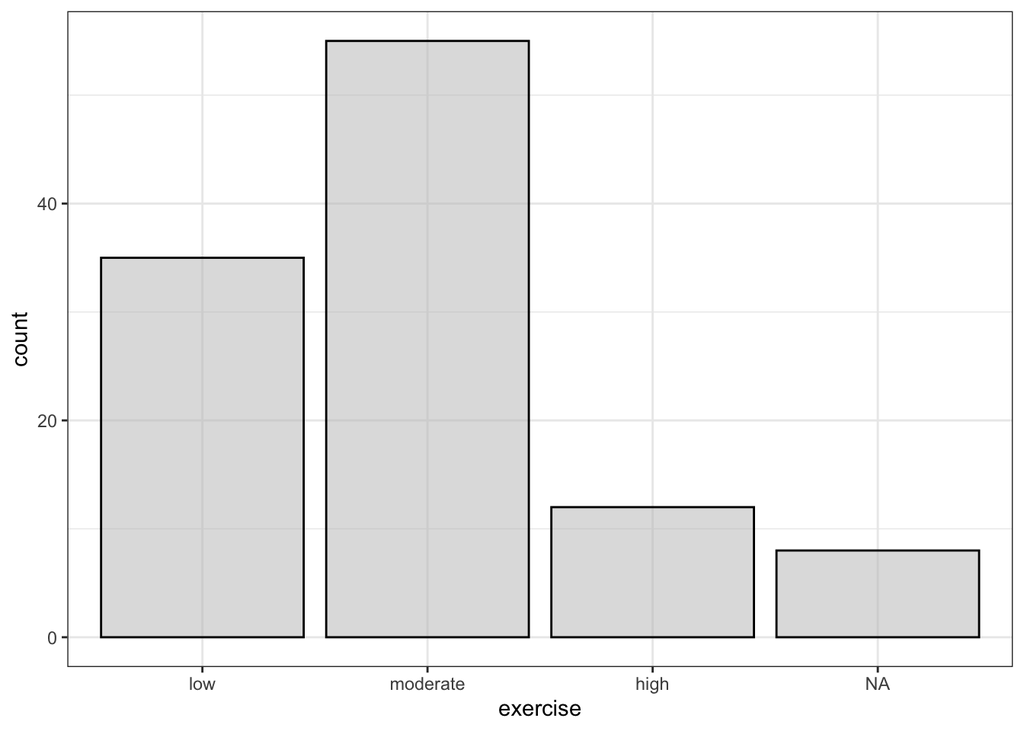

**Solution…**

```r
p <- ggplot(
    plotData |>
      mutate( exercise = factor( exercise, levels=c("low","moderate","high") ) )
  ) +
  geom_bar( aes(x=exercise), fill="gray", color="black", alpha=0.5 ) +
  theme_bw()
p
```

## Plots with panels (faceting) (exercise) 📖

*Needs:* ggplot, aes, geom_point, 🔴facrtor, drop_na, mutate.  
*Gives:* facet_grid, facet_wrap.  
*Practices:* facet_grid, facet_wrap, drop_na, mutate.

Start with the following code that reads the data into `plotData` and produces a scatter plot of the pulse rates in `p`:

```r
suppressPackageStartupMessages( library(tidyverse) )
plotData <- read_csv( "pulseNA.csv" , show_col_types = FALSE) |>
  drop_na( exercise, gender, pulse1, pulse2 )

p <- ggplot(plotData) +
  geom_point( aes(x=pulse1, y=pulse2, color=ran, shape=gender), size=4, alpha=0.5 )
```

Discover how the `facet_grid` and `facet_wrap` functions can be used to create a plot with multiple panels:

```r
p + facet_grid( . ~ exercise )
p + facet_grid( gender ~ . )
p + facet_grid( gender ~ exercise )
p + facet_wrap( ~ year )
```

Note, that the levels of `exercise` are not shown in the correct order. To correct that, change the `plotData` table: convert `exercise` to a factor with levels set to `c("low","moderate","high")`. Then, recreate the plots with `exercise` variable.

**Solution…**

```r
p + facet_grid( . ~ exercise )       # exercise horizontally
p + facet_grid( gender ~ . )         # gender vertically
p + facet_grid( gender ~ exercise )  # gender vertically, exercise horizontally
p + facet_wrap( ~ year )             # year in multiple rows (like writing text)

plotData <- read_csv( "pulseNA.csv" , show_col_types = FALSE) |>
  drop_na( exercise, gender ) |>
  mutate( exercise = factor( exercise, levels=c("low","moderate","high") ) )
p <- ggplot(plotData) +
  geom_point( aes(x=pulse1, y=pulse2, color=ran, shape=gender), size=4, alpha=0.5 )
p + facet_grid( gender ~ exercise )
```

## Retrieving JSON weather list (exercise) 📖

*Needs:* “Lists”.  
*Gives:* as.POSIXct, “epoch”, plot, “fromJSON”, “rjson”.  
*Practices:* str, plot, “fromJSON”, as.POSIXct.

### Weather data source and format

Let’s analyse the weather data from publicly available [Open-meteo archive](https://open-meteo.com/en/docs/historical-weather-api). The data can be obtained in the [JSON file format](https://en.wikipedia.org/wiki/JSON) (in order to see the structure of a JSON file, copy/paste to a browser tab the link provided below in the `url` variable).

### Retrieving the data

Install the `rjson` package when necessary. Then, use the code below to download the weather data for Leiden:

```r
#install.packages("rjson")
library(rjson)
url <- "https://archive-api.open-meteo.com/v1/archive?latitude=52.1583&longitude=4.4931&start_date=2024-07-01&end_date=2024-07-31&hourly=temperature_2m,relative_humidity_2m&timeformat=unixtime&timezone=Europe%2FBerlin"
ls <- rjson::fromJSON( file = url )
```

### Study the structure of the list

- Investigate the `url` variable. Note that in a certain notation the geographical `latitude` and `longitude` of Leiden are provided. Moreover, the period of time is set from `2024-07-01` to `2024-07-31`. Finally, the type of data to be downloaded is specified: `hourly` temperature and relative humidity at `2m` above the ground. The timezone is set to `Europe/Berlin`. Look at [Historical Weather API](https://open-meteo.com/en/docs/historical-weather-api) if you want to find more details.
- Investigate and understand the structure of the `ls` object.
- Find a way to extract the numerical vector of temperatures.
- Find the temperature unit in another element of the `ls` list.
- Note, that the time is provided in [the Unix `epoch` format](https://en.wikipedia.org/wiki/Unix_time) (numbers like `1719784800...` are seconds since `1970-01-01 00:00:00 UTC`). Extract the vector of times and find a way to convert the time to the human-readable format (`as.POSIXct`).
- Finally, plot the temperature against time using the basic `plot` function (find out how to draw lines, not points).

**Solution…**

```r
str(ls)
ls$hourly$temperature_2m
ls$hourly_units$temperature_2m
as.POSIXct(ls$hourly$time)
plot(as.POSIXct(ls$hourly$time), ls$hourly$temperature_2m, type="l")
```

## A function to retrieve weather data (exercise) 📖

*Needs:* “function”, “fromJSON”, as.POSIXct, tibble, stopifnot.  
*Gives:* paste0, is.data.frame, is.numeric.  
*Practices:* “function”, “fromJSON”, as.POSIXct, tibble, paste0, stopifnot, is.data.frame, is.numeric.

### Prerequisite

First, solve the exercise “Retrieving JSON weather list”.

### Build the function

Build a function `getWeatherData` which downloads the weather data for a given location and time period. The function should take the following arguments: `long` (longitude), `lat` (latitude), `startDate`, and `endDate`. The function should return a tibble with columns: `time`, `temperature`, and `humidity`.

*Hint:* To build `url` use the `paste0` function to merge fixed parts with the parameters provided in `long`, `lat`, `startDate` and `endDate`.

**Solution…**

```r
getWeatherData <- function( long, lat, startDate, endDate ) {
  url <- paste0(
    "https://archive-api.open-meteo.com/v1/archive?",
        "latitude=", lat,
        "&longitude=", long,
        "&start_date=", startDate,
        "&end_date=", endDate,
        "&hourly=temperature_2m,relative_humidity_2m&timeformat=unixtime&timezone=Europe%2FBerlin"
  )
  #message( "Accessing URL: ", url )
  ls <- rjson::fromJSON( file = url )
  tibble(
    time = as.POSIXct(ls$hourly$time),
    temperature = ls$hourly$temperature_2m,
    humidity = ls$hourly$relative_humidity_2m
  )
}
```

Here is an example of the function usage and a fragment of the expected result:

```r
d <- getWeatherData( long=4.4931, lat=52.1583, startDate="2024-07-01", endDate="2024-07-31" )
head(d)
```

```
# A tibble: 6 × 3
  time                temperature humidity
  <dttm>                    <dbl>    <dbl>
1 2024-07-01 01:00:00        13.4       82
2 2024-07-01 02:00:00        12.8       83
3 2024-07-01 03:00:00        13.2       83
4 2024-07-01 04:00:00        13.1       84
5 2024-07-01 05:00:00        13.2       83
6 2024-07-01 06:00:00        13.2       84
```

### Implement some tests

You see by eye that the result in `d` is somehow fine. However, in the future you may be improving the function and accidentally you may destroy the output. To prevent this, implement some tests to check whether the function works correctly.

Use the `stopifnot` function to check whether:

- The output is a data frame (`is.data.frame`; a tibble is a data frame).
- The output has the columns `time`, `temperature`, and `humidity`.
- The columns `temperature` and `humidity` are numeric (`is.numeric`).

**Solution…**

```r
d <- getWeatherData( long=4.4931, lat=52.1583, startDate="2024-07-01", endDate="2024-07-31" )
stopifnot( is.data.frame(d) )
stopifnot( all( c("time", "temperature", "humidity") %in% names(d) ) )
stopifnot( is.numeric(d$temperature) )
stopifnot( is.numeric(d$humidity) )
```

## Plot weather data for several cities (exercise) 📖

*Needs:* ggplot, aes, facet_grid, theme_bw, scale_color_continuous, xlab, ylab, 🔴lapply, “function”.  
*Gives:* geom_line, bind_rows.  
*Practices:* “function”, 🔴lapply, bind_rows, ggplot, aes, geom_line, facet_grid, theme_bw, scale_color_continuous, xlab, ylab.

### Prerequisite

First, solve the exercise “A function to retrieve weather data”. Extract the function `getWeatherData` from the solution and use it in the code below.

### Goal

The goal is to produce the function `plotWeather`, which produces a plot of the temperature and humidity for several cities as shown below:

### The plot

The following code is expected to work and reproduce the shown plot. Once your implementation is ready, try it with two additional cities of your choice.

**Solution…**

```r
plotWeather <- function( city2coords, startDate, endDate ) {
  city2weatherData <- lapply( city2coords, function( coords ) {
    getWeatherData(
      long=coords$long, lat=coords$lat,
      startDate=startDate, endDate=endDate
    )
  } )

  d <- bind_rows( city2weatherData, .id="city" )
  ggplot( d, aes(x=time, y=temperature, color=humidity ) ) +
    geom_line() +
    facet_grid( city ~ . ) +
    theme_bw() +
    scale_color_continuous(
      low="yellow", high="blue", name="Humidity\n[rel%]"
    ) +
    xlab( "Date/time" ) +
    ylab( "Temperature [°C]" )
}
```

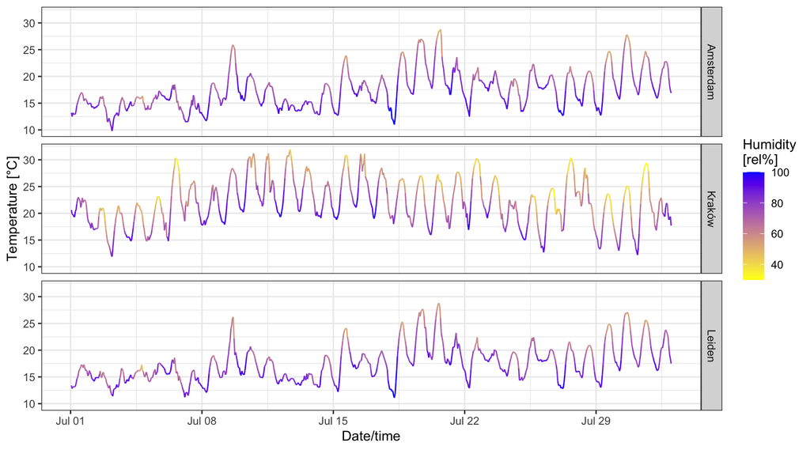

```r
city2coords <- list(
  Leiden = list( long=4.4931, lat=52.1583 ),
  Amsterdam = list( long=4.8897, lat=52.374 ),
  "Kraków" = list( long=19.945, lat=50.0647 )
)

plotWeather( city2coords, startDate="2024-07-01", endDate="2024-08-01" )
```

## Real Data Analysis: Example data analysis problem (cont.) (exercise) 📖

*Files:* rda-NL.rds, rda-UK.csv, rda-PL.tsv, rda-US.xlsx, rda-genes.csv.

Continue with the task provided before.

# Data manipulation 3/3

## Base-R: apply a function to each element of a vector/list (lecture) 👨‍🏫

*Needs:* “function”, sort, sample, seq.  
*Gives:* sapply, lapply.

### An example function

Let’s consider a simple function categorizing age into one of two groups:

```r
ageCategory <- function( age ) {    # define the function
  if( age < 0 ) {
    stop( "Age must be non-negative!" )
  } else if( age < 18 ) {
    return( "child" )
  } else {
    return( "adult" )
  }
}

ageCategory( 15 )                   # call the function with argument age==15
```

```
[1] "child"
```

Note, that due to the way how the function is implemented, it is not possible to pass a vector of ages to the function. The function is not vectorized.

```r
ages <- c( 15, 25, 35, 12 )
ageCategory( ages )                 # this will not work
```

```
Error in if (age < 0) {: the condition has length > 1
```

Another method is needed to call the function for each element of the vector.

### Apply a function to each element, produce a vector (`sapply`)

The base-R `sapply` function can be used to apply a function to each element of a vector.  
Since the example function `ageCategory` returns single texts, the result is a character vector.  
The function which is appled must return scalars (single values).

```r
sapply( ages, ageCategory )         # apply the function to each element of ages
```

```
[1] "child" "adult" "adult" "child"
```

When the input vector is named, the names are preserved in the output:

```r
ages <- c( Alice=15, Bob=25, Charlie=35, Daisy=12 )
sapply( ages, ageCategory )
```

```
  Alice     Bob Charlie   Daisy
"child" "adult" "adult" "child"
```

Moreover, `sapply` can be used to apply a function to each element of a (named) list:

```r
agesList <- list( Alice=15, Bob=25, Charlie=35, Daisy=12 )
sapply( agesList, ageCategory )
```

```
  Alice     Bob Charlie   Daisy
"child" "adult" "adult" "child"
```

Or, using the pipe operator:

```r
agesList |> sapply( ageCategory )
```

```
  Alice     Bob Charlie   Daisy
"child" "adult" "adult" "child"
```

### Apply a function to each element, produce a list (`lapply`)

The base-R `lapply` function can be used to apply a function to each element of an iterable (possibly named) object (e.g. a vector, factor, list). The result is a list.

Let’s try to generate a list of random number of random grades for several students:

```r
name2gradesNum <- c( "Alice"=5, "Bob"=3, "Charlie"=6 )

genGrades <- function( gradesNum ) {
  sample( seq(1,10,0.5), size=gradesNum, replace=TRUE )
}

lapply( name2gradesNum, genGrades )          # list with random grades
```

```
$Alice
[1] 8.0 4.0 2.5 3.0 7.5

$Bob
[1] 9.5 8.0 2.0

$Charlie
[1] 5.0 2.5 3.0 7.0 3.0 1.5
```

Or, using the pipe operator:

```r
name2gradesNum |> lapply( genGrades )
```

```
$Alice
[1] 4.5 2.0 1.0 5.5 6.0

$Bob
[1] 8.0 4.5 2.5

$Charlie
[1] 2.5 9.5 7.0 3.0 2.5 1.5
```

### Anonymous/lambda function

Note, that the function to be applied can be specified directly in the `lapply` call (so called anonymous function or lambda function):

```r
name2gradesNum |>
  lapply( function( gradesNum ) sample( seq(1,10,0.5), size=gradesNum, replace=TRUE ) )
```

```
$Alice
[1] 9.5 2.0 9.0 9.5 3.5

$Bob
[1] 3.5 1.5 2.0

$Charlie
[1] 1.5 3.5 5.5 4.5 3.0 1.0
```

Or using even shorter syntax with the new lambda function syntax:

```r
name2gradesNum |>
  lapply( \( gradesNum ) sample( seq(1,10,0.5), size=gradesNum, replace=TRUE ) )
```

```
$Alice
[1] 9.0 4.0 2.5 7.0 5.5

$Bob
[1] 5.0 6.5 5.0

$Charlie
[1] 6.0 2.0 8.5 3.0 7.5 3.0
```

### Chaining

It is possible to build chains/pipelines (similar to operations on tables):

```r
name2gradesNum |>
  lapply( \( gradesNum ) sample( seq(1,10,0.5), size=gradesNum, replace=TRUE ) ) |>
  lapply( sort )        # use standard function sort(...) to sort the grades
```

```
$Alice
[1] 1.5 3.0 9.0 9.5 9.5

$Bob
[1] 4.5 4.5 7.5

$Charlie
[1] 2.5 2.5 4.0 5.5 7.0 9.5
```

## Tidyverse: apply a function to each element of a vector/list (lecture) 👩‍🏫

*Needs:* “function”, sort, sample, seq.  
*Gives:* map, pmap.

### Applying functions with one argument iterating over a vector/list

Tidyverse provides a function `map` to apply a function to each element of a vector or list.

```r
name2gradesNum <- c( "Alice"=5, "Bob"=3, "Charlie"=6 )

genGrades <- function( gradesNum ) {
  sample( seq(1,10,0.5), size=gradesNum, replace=TRUE )
}

map( name2gradesNum, genGrades )          # equivalent to lapply
```

```
$Alice
[1] 10.0  8.5  9.0  6.5  5.0

$Bob
[1] 6.0 8.5 4.5

$Charlie
[1] 3.5 1.0 7.0 7.5 3.0 5.0
```

This function supports anonymous functions (lambda functions) as well:

```r
name2gradesNum |>
  map( \( gradesNum ) sample( seq(1,10,0.5), size=gradesNum, replace=TRUE ) ) |>
  map( sort ) |>
  map( head, n=2 )  # take the two lowest grades
```

```
$Alice
[1] 1.0 5.5

$Bob
[1] 7.5 9.0

$Charlie
[1] 3.0 3.5
```

Another notation, using the formula syntax is possible.  
When the formula syntax is used, a fixed names is used for the argument: `.x`

```r
name2gradesNum |>
  map( ~ sample( seq(1,10,0.5), size=.x, replace=TRUE ) ) |>
  map( sort ) |>
  map( ~ tail(.x, n=2) )  # take the two highest grades
```

```
$Alice
[1] 9.0 9.5

$Bob
[1] 3.5 3.5

$Charlie
[1] 6.5 8.0
```

### Applying functions with many arguments iterating over many vectors/lists or tibble rows

With `pmap` many arguments can be passed to a function.  
The function is applied to arguments constructed from the first elements of each iterable, then for the second elements, and so on.

```r
infos <- list(               # could also be a tibble!
  name = list( "Alice", "Bob", "Charlie" ),   # a list of character vectors
  topic = c( "Math", "Physics", "Biology" ),  # a text vector
  grade = c( 7, 8, 7.5 )                      # a numerical vector
)

pmap(
  infos,
  \( name, grade, topic ) paste( name, "got", grade, "in", topic )
)
```

```
[[1]]
[1] "Alice got 7 in Math"

[[2]]
[1] "Bob got 8 in Physics"

[[3]]
[1] "Charlie got 7.5 in Biology"
```

## Iterating over list elements with lapply and sapply (exercise) 📖

*Needs:* list, mean, length, sort.  
*Gives:* lapply, sapply, any.  
*Practices:* lapply, sapply, any.

Base-R provides mechanisms to apply a function to each element of a list (or another iterable object, e.g. a vector) and automatically build a list with results. If the iterable object has names, they are copied to the output list.

### Example list

Let’s consider a simple list of grades:

```r
grades <- list(
  Bob = c( 6, 7, NA, 7, NA, 5, 5, 8 ),
  Alice = c( 8, 9, 7.5, 8, 9 ),
  Daisy = c( 8, NA, 6.5, 6.5, 7, 8, 7 ),
  Charlie = c( 9, 7, 9 ),
  Eve = c( 5.5 )
)
```

### Calculations

- Find out how to use the `lapply` function to calculate the `mean` of the grades of each student.
- Find out how in `lapply` to pass additional arguments for the `mean` function, so you can calculate the mean omitting the missing values.
- Replace `lapply` with `sapply`. Observe how the type of the result changed.
- Calculate the number of grades of each student (including the missing ones). This should be a named numerical vector.
- Produce a numerical vector with counts of missing values for each student. Hint: use apply functions twice (with `is.na` and `sum`).
- Produce a logical telling whether a name has any missing grades. Hint: understand functions `any` or `all`.
- Reorder the list of grades so, that the names are in the alphabetical order, and the grades are sorted from the largest to the smallest. Don’t drop `NA` values (just keep them at the end).

**Solution…**

```r
lapply( grades, mean )
lapply( grades, mean, na.rm = TRUE ) # additional arguments to mean
sapply( grades, mean, na.rm = TRUE )
sapply( grades, length )
sapply( lapply( grades, is.na ), sum )
sapply( lapply( grades, is.na ), any )

n2g <- lapply( grades, sort, decreasing=TRUE, na.last=TRUE )
n2g[ sort( names( n2g ) ) ]
```

## Merge tables (lecture) 👨‍🏫

`*_join(...)` is a family of functions for combining two tibbles on common `variable(s)` called `key`.

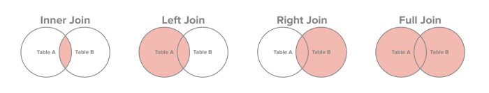

For example, take a group of people (n=7) for which we have collected age and height data:

```r
# height
df1 <- tibble(name = c("Isa","Jaylinn","Mila","Milas","Yara"),
           height = c(160, 172, 182, 157, 162))
df1
```

```
# A tibble: 5 × 2
  name    height
  <chr>    <dbl>
1 Isa        160
2 Jaylinn    172
3 Mila       182
4 Milas      157
5 Yara       162
```

```r
# age
df2 <- tibble(name = c("Fiene","Jaylinn","Mila","Noah","Yara"),
           age = c(20,24,17,23,17))
df2
```

```
# A tibble: 5 × 2
  name      age
  <chr>   <dbl>
1 Fiene      20
2 Jaylinn    24
3 Mila       17
4 Noah       23
5 Yara       17
```

The information here is incomplete, for some we have only `height` and for some only `age`. Now we want to combine these tibbles into a single table with variables `name`, `age` and `height`. We can do this with a join function which is able to combine observations by matching on the common variable(s) between the two tibbles also known as *keys*. Matching is done by one or more variables, in this case the variable `name`.

**Note** that for a proper joining of data, the matched variable(s), also known as the key, must be unique in both tibbles.

**inner_join** Return all rows in `df1` where there are matching values of `name` in `df2` and all columns in both `df1` and `df2`:

```r
inner_join(df1,df2, by = "name")
```

```
# A tibble: 3 × 3
  name    height   age
  <chr>    <dbl> <dbl>
1 Jaylinn    172    24
2 Mila       182    17
3 Yara       162    17
```

**left_join** Return all rows from `df1` and all columns in both `df1` and `df2`, `NA` for missing values in `df2`:

```r
left_join(df1,df2, by = "name")
```

```
# A tibble: 5 × 3
  name    height   age
  <chr>    <dbl> <dbl>
1 Isa        160    NA
2 Jaylinn    172    24
3 Mila       182    17
4 Milas      157    NA
5 Yara       162    17
```

**full_join** All rows and all columns in `df1` and `df2`.

```r
full_join(df1,df2, by = "name")
```

```
# A tibble: 7 × 3
  name    height   age
  <chr>    <dbl> <dbl>
1 Isa        160    NA
2 Jaylinn    172    24
3 Mila       182    17
4 Milas      157    NA
5 Yara       162    17
6 Fiene       NA    20
7 Noah        NA    23
```

## Bind tables (lecture) 👩‍🏫

Often we have different data sets with i) the same set of variables or ii) same set of observations but different variables which we would like to combine:

- bind_rows(…) function creates a new tibble from a set of tibbles with not necessarily common variables.
  - treats tibbles as a collection of unordered variables.
- bind_cols(…) function creates a new tibble from a set of tibbles with common observations.
  - expects the same number of observations in each tibble

```r
t1 <- tibble(a=1:3, b=letters[1:3])
t2 <- tibble(a=4:6, b=letters[4:6])
t3 <- tibble(a=6:8)
```

```r
bind_rows(t1,t2)  # compatible
```

```
# A tibble: 6 × 2
      a b
  <int> <chr>
1     1 a
2     2 b
3     3 c
4     4 d
5     5 e
6     6 f
```

```r
bind_rows(t1,t3)  # incompatible
```

```
# A tibble: 6 × 2
      a b
  <int> <chr>
1     1 a
2     2 b
3     3 c
4     6 <NA>
5     7 <NA>
6     8 <NA>
```

To combine variables column-wise use bind_cols:

```r
t4 <- tibble(b=letters[6:8])
bind_cols(t3,t4)
```

```
# A tibble: 3 × 2
      a b
  <int> <chr>
1     6 f
2     7 g
3     8 h
```

Note that the user is responsible for the order of observations in each tibble.

## Merging patients data (exercise) 📖

Let’s consider the following two tables describing a few patients and some samples taken from them.

```r
patientInfos <- tibble(
  id = c( "PAT563", "PAT224", "PAT993", "PAT118", "PAT034", "PAT224" ),
  name = c("Isa","Jaylinn","Koen", "Mila","Tobias", "Jaylinn"),
  birthday = c("2000-01-01", "1999-02-03", "1995-06-06", "2001-03-04", "2002-04-05", "1999-02-04")
)

sampleInfos <- tibble(
  id = c( "PAT563", "PAT224", "PAT118", "PAT555", "PAT034", "PAT224", "PAT563", "PAT224" ),
  sampleDate = c("2013-01-01", "2015-02-03", "2015-03-04", "2016-12-01", "2017-04-05", "2017-04-05", "2021-04-05", "2021-04-06"),
  sampleType = c("blood", "urine", "blood", "urine", "blood", "blood", "blood", "urine")
)
```

- Are there any columns which could not have duplicates in the `patientInfos` table?
- Decide how to handle possible `id` duplicates in the `patientInfos` table.
- Merge the two tables on the `id` column. Interpret the result of different types of `join`, given the nature of the data.

**Solution…**

```r
any( duplicated(patientInfos$id) )
duplicatedIds <- patientInfos$id[ duplicated(patientInfos$id) ] |> unique()
correctedPatientInfos <- patientInfos |> filter( !( id %in% duplicatedIds ) )
correctedPatientInfos

# All patients are kept, NA when no samples, multiple rows when many samples
left_join( correctedPatientInfos, sampleInfos, by="id" )

# All samples are kept, even if the patient info is not present (was removed)
right_join( correctedPatientInfos, sampleInfos, by="id" )

# All possible combinations of patients and samples matching by id
full_join( correctedPatientInfos, sampleInfos, by="id" )

inner_join( correctedPatientInfos, sampleInfos, by="id" )
```

## Merge tables (exercise) 📖

*Files:* pulseNA.csv, survey.csv.  
*Needs:* 🔴“LcJoin”, “survey.csv”, “pulseNA.csv”, 🔴“LcMutate”, 🔴tidyverse.

1. **Unique keys** To consistently merge tables with the given key(s) it is important to make sure that the chosen key(s) contain no duplicates.
- 1.1) Take a look at the function `distinct` (?distinct) and use it to check whether the variable `name` in the pulse dataset has no duplicates and each name can uniquely identify an observation(row) in the table.
- 1.2) Do the same test as in 1.1 with the function `duplicated` (?duplicated)
2. The variable `name` in the `survey` dataset has duplicates, can you find other variables that would make it distinct when combined with `name`?
3. Print the rows with duplicate names in `pulse` and `survey` dataset.

**Solution…**

```r
# 1
#
# 1.1
#
# There are less distinct names than total nr. of observations, therefore some
# names must be duplicated.
#
check_names <- list( nr_of_distinct_names = pulse |>  distinct(name) |>  nrow(),
   nr_of_names  = pulse |> nrow())

# Test equality: if FALSE then there are duplicates otherwise not.
check_names$nr_of_distinct_names == check_names$nr_of_names

# 1.2
#
pulse |> summarise(nr_of_distinct_names = sum( ! duplicated(name)),  nr_of_names = n() )

# 2
(survey |> distinct(name,height) |> nrow() ) == (survey |> nrow())
(survey |> distinct(name,span1) |> nrow() ) == (survey |> nrow())
(survey |> distinct(name,age) |> nrow() ) == (survey |> nrow())

# 3
# pulse
pulse_dupl_names <- pulse |>  filter(duplicated(name)) |> pull(name)
pulse |>  filter(name %in% pulse_dupl_names) |>  arrange(name)
# survey
survey_dupl_names <- survey |>  filter(duplicated(name)) |> pull(name)
survey |>  filter(name %in% survey_dupl_names) |>  arrange(name)
```

## Bind tables (exercise) 📖

1. In the survey dataset what is the mean height of the first 15 and the 30 observations combined?
2. Convert the list below to a tibble with variables `name` and `height`:

```r
heights  <- list(Andre=182.88, Benjamin=175.26, Alyson=173, Edward=175)
```

3. How many duplications of (`name`,`height`) do you find in the combined `survey` and `pulse` dataset?

**Solution…**

```r
#
survey <- read_csv("survey.csv", show_col_types = FALSE)
pulse  <- read_csv("pulseNA.csv", show_col_types = FALSE)

# 1)
bind_rows(survey |>  head(15), survey |>  tail(30)) |>
  summarise(mean_height=mean(height, na.rm=TRUE))

# 2)
heights  <- list(Andre=182.88, Benjamin=175.26, Alyson=173, Edward=175)
lapply(names(heights),
       function(name_) tibble(name=name_, height=heights[[name_]])) |>
  bind_rows()

# 3)
bind_rows(pulse |> select(name, height), survey |> select(name, height)) |>
    duplicated() |>
    sum()
```

## Date/Time (lecture) 👨‍🏫

**`lubridate`** is a sub-package in **tidyverse** for working with dates and times in R. Handling date-time data can be tricky due to different formats, time zones and `lubridate` simplifies it by providing functions for parsing, extracting, and manipulating dates and times.

#### 1. Parsing Dates and Times

`lubridate` has the following functions to convert date-time strings into proper date or datetime objects in R:

- **`ymd()`**: Parses dates in “Year-Month-Day” format.
- **`mdy()`**: Parses dates in “Month-Day-Year” format.
- **`dmy()`**: Parses dates in “Day-Month-Year” format.

Similarly, for date-times (dates with times included), `lubridate` offers:

- **`ymd_hms()`**: For “Year-Month-Day Hour:Minute:Second”.
- **`mdy_hm()`**: For “Month-Day-Year Hour:Minute”.

**Example**:

```r
library(lubridate)
date1 <- dmy("18-11-2024")
date1
```

```
[1] "2024-11-18"
```

```r
date1 |> class()
```

```
[1] "Date"
```

```r
date2 <- dmy_hms("21-11-2024 11:15:00")
date2
```

```
[1] "2024-11-21 11:15:00 UTC"
```

#### 2. Extracting Components of Dates and Times

Once you have a date or date-time object, you often need to extract components like the year, month, or day. `lubridate` provides straightforward functions for this:

- **`year()`**: Extracts the year.
- **`month()`**: Extracts the month.
- **`day()`**: Extracts the day of the month.
- **`hour()`, `minute()`, `second()`**: Extracts the hour, minute, or second from a date-time.

**Example**:

```r
# Extract components
year(date1)
month(date1)
day(date1)
hour(date2)
```

```
[1] 2024
[1] 11
[1] 18
[1] 11
```

#### 3. Modifying Dates and Times

You can also modify parts of a date-time object directly. For instance, if you want to change the month or add days to a date, `lubridate` provides functions like `update()` and simple arithmetic.

- **`update()`**: Modifies specific parts of a date-time object.
- **Arithmetic**: Adding or subtracting days, months, etc.

**Example**:

```r
# Changing the month to December
date1 <- update(date1, month = 12)

# Adding "0001-01-03 01:02:25" to a date1:
date1 + years(1) + months(1) + days(3) + hours(1) + minutes(2) + seconds(25)
```

**Note:** `years`, `months`, etc. will create periods of date/time for date calculation, not to be confused with `year`, `month`, etc. which are used for extraction.

#### 4. Working with Intervals and Durations

For date-based calculations, `lubridate` provides **intervals**, **durations**, and **periods** to help calculate differences between dates or add specific time amounts.

- **`interval()`**: Creates an interval between two dates.
- **`duration()`**: Measures exact time in seconds (useful for precise calculations).
- **`period()`**: Measures human-readable time units like days, months, or years.

**Example**:

```r
# interval between two dates
intrvl1 <- interval( dmy_hms("18-11-2024 11:15:00"), dmy_hms("22-11-2024 11:15:00"))
intrvl1
```

```
[1] 2024-11-18 11:15:00 UTC--2024-11-22 11:15:00 UTC
```

```r
intrvl1 |> class()
```

```
[1] "Interval"
attr(,"package")
[1] "lubridate"
```

```r
# duration in days
as.duration(intrvl1) /ddays(1)
```

```
[1] 4
```

```r
# period
as.period(intrvl1)
```

```
[1] "4d 0H 0M 0S"
```

#### Summary

`lubridate` simplifies date-time manipulation provides:

- **Easy parsing** functions to convert strings to dates.
- **Extraction tools** for getting specific date-time components.
- **Modification options** to adjust dates and times.
- **Intervals and durations** for date calculations.

## Date/Time (exercise) 📖

```r
new_years_eve # December 31, 2024 at 6 PM
```

```
[1] "2024-12-31 18:00:00 UTC"
```

```r
format(new_years_eve, "%Y-%m-%d")
```

```
[1] "2024-12-31"
```

where `%Y`, `%m` and `%d` stands for year, month and day respectively. See section under ?strptime for more formatting options.

**Exercise** format `new_years_eve` in the following formats:

```yaml
[1] "Tuesday, 31 December 2024"
[1] "Tue, Dec 31"
[1] "2024-12-31 18:00:00"
[1] "2024-12-31 06:00 PM"
[1] "Day 366 of the year, Week 52"
```

2. `storms` dataset is part of the tidyverse package. Create a new dataframe `storms_dates` where the date related variables are replaced with variable `date` of type `Date`.
3. List top 3 storms with longest period in `storms_dates`. Note that the storms are monitored and reported often every 6 hours but also in other intervals.

```r
library(tidyverse)
storms |> str()
```

```
tibble [19,537 × 13] (S3: tbl_df/tbl/data.frame)
 $ name                        : chr [1:19537] "Amy" "Amy" "Amy" "Amy" ...
 $ year                        : num [1:19537] 1975 1975 1975 1975 1975 ...
 $ month                       : num [1:19537] 6 6 6 6 6 6 6 6 6 6 ...
 $ day                         : int [1:19537] 27 27 27 27 28 28 28 28 29 29 ...
 $ hour                        : num [1:19537] 0 6 12 18 0 6 12 18 0 6 ...
 $ lat                         : num [1:19537] 27.5 28.5 29.5 30.5 31.5 32.4 33.3 34 34.4 34 ...
 $ long                        : num [1:19537] -79 -79 -79 -79 -78.8 -78.7 -78 -77 -75.8 -74.8 ...
 $ status                      : Factor w/ 9 levels "disturbance",..: 7 7 7 7 7 7 7 7 8 8 ...
 $ category                    : num [1:19537] NA NA NA NA NA NA NA NA NA NA ...
 $ wind                        : int [1:19537] 25 25 25 25 25 25 25 30 35 40 ...
 $ pressure                    : int [1:19537] 1013 1013 1013 1013 1012 1012 1011 1006 1004 1002 ...
 $ tropicalstorm_force_diameter: int [1:19537] NA NA NA NA NA NA NA NA NA NA ...
 $ hurricane_force_diameter    : int [1:19537] NA NA NA NA NA NA NA NA NA NA ...
```

**Solution…**

```r
# 1)
new_years_eve <- dmy_hms("31/12/2024 18:00:00")
format(new_years_eve, "%A, %d %B %Y")
format(new_years_eve, "%a, %b %d")
format(new_years_eve, "%Y-%m-%d %H:%M:%S")
format(new_years_eve, "%Y-%m-%d %I:%M %p")
format(new_years_eve, "Day %j of the year, Week %U")

# 2)
storms_dates <- storms |>
  mutate(date=dmy_hms(
    paste(paste(day,month,year,sep="-"),
          paste(hour,"00","00",sep=":"))
    )
  ) |>
  select(-year,-month,-day,-hour) |>
  select(name,date,everything())

# 3)
# Note: this solution does not catch storms crossing over years.
storms_dates |>
  mutate(year=year(date)) |>
  group_by(name,year) |>
  mutate(period=as.period(as.interval(min(date),max(date)))) |>
  distinct(name,year,period) |>
  ungroup() |>
  arrange(desc(period)) |>
  head(3)
```

# Self-Study Assignment

## Real Data Analysis: Example data analysis problem (cont.) (exercise) 📖

*Files:* rda-NL.rds, rda-UK.csv, rda-PL.tsv, rda-US.xlsx, rda-genes.csv.

Continue with the task provided before.